# innovation

\begin{eqnarray} && b_d = \left( \frac{(1-s_d^e)(1-\gamma)\psi_d \chi_d^e}{(1-s_d^i)\chi_d^i} \right)^{(1-\gamma)/\gamma}\\ && b_n = \left( \frac{(1-s_n^e)(1-\gamma)\psi_n \chi_n^e}{(1-s_n^i)\chi_n^i} \right)^{(1-\gamma)/\gamma}\\ && (\rho + z_d)(1-s_d^e) \chi_d^e \psi_d = \frac{L_d(\lambda_d-1)}{1-\alpha}-(1-s_d^i)\chi_d^ib_d^{1/1-\gamma}\\ && (\rho + z_n)(1-s_n^e) \chi_n^e \psi_n = \frac{L_n(\lambda_n-1)}{1-\theta}-(1-s_n^i)\chi_n^ib_n^{1/1-\gamma} \\ && L_n+L_d+ RD = 1 \\ && rK=w\left(\frac{\theta}{1-\theta}L_n+\frac{\alpha}{1-\alpha}L_d \right) \\ && P_d = \frac{\lambda_d r^\alpha w^{1-\alpha}}{A} \\ && 1 = \frac{\lambda_n r^\theta w^{1-\theta}}{\Theta} \\ && \tau_d = b_d + z_d\\ && \tau_n = b_n + z_n\\ && r = \left(\rho + \delta + \frac{\tau_d \log(\lambda_d)}{1-\alpha}\right)(1-s^x)P_d \\ && \left(\frac{\tau_d \log(\lambda_d)}{1-\alpha}+ \delta \right)K = D \\ && C = N \\ && RD = \chi_d^i b_d^{1/1-\gamma}+\chi_n^i b_n^{1/1-\gamma}+\chi_d^e\psi_d z_d + \chi_n^e\psi_n z_n\\ &&N = \left(\frac{\theta}{1-\theta}\frac{w}{r}\right)^\theta L_n\\ &&D = \left(\frac{\alpha}{1-\alpha}\frac{w}{r}\right)^\alpha L_d\\ && W = \frac{1}{\rho}\left(\log C_0 + \frac{g_C}{\rho} \right) \end{eqnarray}

```python
import numpy as np
import scipy.optimize
from scipy.integrate import odeint
import matplotlib.pyplot as plt
from scipy.integrate import trapz
import csv
from numba import jit

b_nt=.1
b_dt=.09
z_nt=.06
z_dt=.04
g_ct=.02
g_rt=-.02
n=100
vs = np.linspace(0,.5, n)
class innovation(object):
    def __init__(self, alpha=.33, theta=.33, delta=.05, rho=.03, gamma =.6, lambda_d=1.21390951, lambda_n=1.02788162,
                 psi_d=.18, psi_n = 0.2, chi_ed= 4.65252389, chi_en = 1.66782674, s_x =0, s_ed = 0, s_en=0, s_id=0.2, s_in=0.2,
                 Qn = 1.0, Qd=1.0, chi_id= 4.65252389, chi_in = 1.66782674, iota_n = 0, iota_d =0,x0=np.ones(16)/2):
                 self.alpha, self.theta, self.delta, self.rho, self.gamma = alpha, theta, delta, rho, gamma
                 self.lambda_d, self.lambda_n = lambda_d, lambda_n
                 self.psi_d, self.psi_n, self.chi_ed, self.chi_en = psi_d, psi_n, chi_ed, chi_en
                 self.s_x, self.s_ed, self.s_en, self.s_id, self.s_in = s_x,s_ed, s_en, s_id, s_in
                 self.Qn, self.Qd = Qn, Qd
                 self.chi_id, self.chi_in = chi_id, chi_in
                 self.iota_n, self.iota_d = iota_n, iota_d
                 self.alpham = (self.alpha**self.alpha)*(1-self.alpha)**(1-self.alpha)
                 self.thetam = (self.theta**self.theta)*(1-self.theta)**(1-self.theta)
                 self.x0 = x0

    def Funcs(self,x,corr_call):
        b_n, b_d, z_n, z_d, tau_n, tau_d = x[0:6]
        Ln, Ld = x[6:8]
        D, N, C, K, RD = x[8:13]
        w, r, Pd = x[13:]

        if corr_call:
            self.s_x = 1-1/self.lambda_d

        Q = self.Qn*self.Qd**((self.theta)/(1-self.alpha))
        F=np.zeros(16)
        alpham = (self.alpha**self.alpha)*(1-self.alpha)**(1-self.alpha)
        thetam = (self.theta**self.theta)*(1-self.theta)**(1-self.theta)
        gammah = 1.0/(1-self.gamma)
        An = (1.0-self.s_en)*(1-self.gamma)*self.psi_n*self.chi_en
        Bn = (1.0-self.s_in)*self.chi_in
        Ad = (1.0-self.s_ed)*(1-self.gamma)*self.psi_d*self.chi_ed
        Bd = (1.0-self.s_id)*self.chi_id
        F[0]=b_n - z_n*(An/Bn)**((1-self.gamma)/self.gamma)
        F[1]=b_d - z_d*(Ad/Bd)**((1-self.gamma)/self.gamma)
        F[2]=((self.rho+z_d)*(1.0-self.s_ed)*self.chi_ed*self.psi_d*z_d**(self.gamma/(1-self.gamma))
              - Ld*(self.lambda_d -1)/(1.0-self.alpha)+(1-self.s_id)*self.chi_id*b_d**gammah)
        F[3]=((self.rho+z_n)*(1.0-self.s_en)*self.chi_en*self.psi_n*z_n**(self.gamma/(1-self.gamma))
              - Ln*(self.lambda_n -1)/(1.0-self.theta)+(1-self.s_in)*self.chi_in*b_n**gammah)
        F[4]=1-Ln-Ld-RD
        F[5]=K*r - w*(self.theta/(1-self.theta)*Ln + self.alpha/(1-self.alpha)*Ld)
        F[6]=Pd - self.lambda_d*r**self.alpha*w**(1-self.alpha)/(alpham)
        F[7]=1 - self.lambda_n*r**self.theta*w**(1-self.theta)/(thetam)
        F[8]=tau_n - b_n - z_n
        F[9]=tau_d - b_d - z_d
        F[10]=r-(self.rho+self.delta+tau_d*np.log(self.lambda_d)/(1-self.alpha))*(1-self.s_x)*Pd
        F[11]=(tau_d*np.log(self.lambda_d)/(1-self.alpha)+self.delta)*K-D
        F[12]=C-N
        F[13]=(RD-self.chi_id*b_d**gammah-self.chi_in*b_n**gammah-self.chi_ed*self.psi_d*z_d**gammah
               -self.chi_en*self.psi_n*z_n**gammah)
        F[14]=N-(self.theta/(1-self.theta)*w/r)**self.theta*Ln
        F[15]=D-(self.alpha/(1-self.alpha)*w/r)**self.alpha*Ld
        return F



    def equilibrium(self,correct_call=False):
        x0=self.x0
        sol= scipy.optimize.root(self.Funcs, x0, correct_call, method = 'hybr')
        x0 = sol.x
        self.b_n=sol.x[0]
        self.b_d=sol.x[1]
        self.z_n=sol.x[2]
        self.z_d=sol.x[3]
        self.tau_n=sol.x[4]
        self.tau_d=sol.x[5]
        self.g_c = self.theta/(1-self.alpha)*self.tau_d*np.log(self.lambda_d)+self.tau_n*np.log(self.lambda_n)
        self.g_r = self.tau_n*np.log(self.lambda_n) - (1-self.theta)/(1-self.alpha)*self.tau_d*np.log(self.lambda_d)
        self.C = sol.x[10]
        self.Ln = sol.x[6]
        self.Ld = sol.x[7]
        self.D  = sol.x[8]
        self.K  = sol.x[11]
        self.RD = sol.x[12]
        self.w  = sol.x[13]
        self.r  = sol.x[14]
        self.R  = self.g_c+self.rho
        self.p_d= sol.x[15]
        self.Kn = (self.theta/(1-self.theta))*self.Ln*self.w/self.r
        self.Kd = (self.alpha/(1-self.alpha))*self.Ld*self.w/self.r
        self.value_n = ((self.w*(self.lambda_n-1)*self.Ln/(1-self.theta)-self.w*(1-self.s_in)*self.chi_in*self.b_n**(1/(1-self.gamma)))
                       /(self.rho+self.z_n))
        self.value_d = ((self.w*(self.lambda_d-1)*self.Ld/(1-self.alpha)-self.w*(1-self.s_id)*self.chi_id*self.b_d**(1/(1-self.gamma)))
                       /(self.rho+self.z_d))

        self.T = (self.s_en*self.psi_n*self.chi_en*self.z_n**(1/(1-self.gamma))+
                  self.s_ed*self.psi_d*self.chi_ed*self.z_d**(1/(1-self.gamma))+
                  self.s_in*self.chi_in*self.b_n**(1/(1-self.gamma))+
                  self.s_id*self.chi_id*self.b_d**(1/(1-self.gamma)))*self.w+self.s_x*self.p_d*self.D

        #return np.array([self.b_n, self.b_d, self.z_n, self.z_d, self.g_c, self.g_r])
        self.init_C = self.C
        self.init_tau_n = self.tau_n
        self.init_tau_d = self.tau_d
        self.init_g_C = self.g_c
        self.init_k   = self.K
        return  np.array([self.g_c, self.init_g_C,self.tau_n, self.tau_d,self.z_n, self.b_n, self.z_d,
                 self.b_d, self.Ln, self.Ld, self.Kn, self.Kd, self.K])


#         return  ('CE = ', 1, 'TE = ', 1, 'optimal growth = ', self.g_c.round(decimals=2),
#                  'decentral growth = ', self.init_g_C.round(decimals=2), 'tau_n = ', self.tau_n.round(decimals=2),
#                 'tau_d = ', self.tau_d.round(decimals=2),'z_n = ', self.z_n.round(decimals=2),
#                  'b_n = ', self.b_n.round(decimals=2), 'z_d = ', self.z_d.round(decimals=2),
#                  'b_d = ', self.b_d.round(decimals=2),'Ln = ', self.Ln.round(decimals=2),
#                  'Ld = ', self.Ld.round(decimals=2), 'Kn = ', self.Kn.round(decimals=2),
#                  'Kd = ', self.Kd.round(decimals=2), 'K = ', self.K.round(decimals=2))
```

```python
    def distance(self,x,targets,corr_call,alt_calib):
        if alt_calib:
            self.psi_n = self.psi_d = x[0]
            self.lambda_n = self.lambda_d = x[1]
            self.chi_ed=self.chi_id=self.chi_en=self.chi_in=x[2]
        else:
            self.psi_n = x[0]
            self.psi_d = x[1]
            self.lambda_n = x[2]
            self.lambda_d = x[3]
            self.chi_ed=self.chi_id=x[4]
            self.chi_en=self.chi_in=x[5]
        self.equilibrium(correct_call=corr_call)
        if alt_calib:
            M = [0,0,0]
            M[0] = targets[0]-(self.b_n*self.Ln+self.b_d*self.Ld)/(self.Ln+self.Ld)
            M[1] = targets[1]-(self.z_n*self.Ln+self.z_d*self.Ld)/(self.Ln+self.Ld)
            M[2]=targets[2]-self.g_c
        else:
            M=[0,0,0,0,0,0]
            M[0]=targets[0]-self.b_n
            M[1]=targets[1]-self.b_d
            M[2]=targets[2]-self.z_d
            M[3]=targets[3]-self.z_n
            M[4]=targets[4]-self.g_c
            M[5]=targets[5]-self.g_r

        return M

    def inn_distance(self,x):
        self.s_in, self.s_id = x
        self.s_en, self.s_ed = max(0,(self.s_in-self.gamma)/(1-self.gamma)),max(0,(self.s_id-self.gamma)/(1-self.gamma))
        self.equilibrium()
        M = np.array([self.tau_n,self.tau_d])-self.optimum_inn
        return M

    def calibration(self,targets,corr_call=False,alt_calib=False):
        if alt_calib:
            x0= [.2, 1.12, 2]
        else:
            x0= [.2, .2, 1.12, 1.24, 2,2]
        if corr_call:
            self.s_en = (self.s_in-self.gamma)/(1-self.gamma)
            self.s_ed = (self.s_id-self.gamma)/(1-self.gamma)
        args = targets, corr_call,alt_calib
        return scipy.optimize.leastsq(self.distance, x0,args)



    def optimum_subsidy(self):
        x0= [.8,.8]
        n = 100
        gammas = np.linspace(.4,.8,n)

        s_optimum = np.zeros((2,n))
        self.s_x = 1-1/self.lambda_d

        for index,gamma in enumerate(gammas):
            self.gamma = gamma
            self.planner_ss()
            sol=scipy.optimize.leastsq(self.inn_distance,x0)
            s_optimum[:,index]=sol[0]

        %matplotlib inline
        plt.plot(gammas,s_optimum[0,:],'r',linewidth=2,label='Consumption')
        plt.plot(gammas,s_optimum[1,:],'b',linewidth=2,label='Investment')
        plt.xlabel(r'$\gamma $',fontsize=18)
        plt.ylabel('R&D Subsidy')
        plt.legend(loc='best')
        plt.title('Optimal R&D Subsidy')
        plt.savefig('./com-stats/gamma.pdf')

    def planner_eq(self, x):

        K_n   = x[0]
        K_d   = x[1]
        L_n   = x[2]
        L_d   = x[3]
        tau_n = x[4]
        tau_d = x[5]
        S = [0,0,0,0,0,0]

        psi_nbar = (self.psi_n+self.psi_n**(1/self.gamma))/(1+self.psi_n**((1-self.gamma)/self.gamma))**(1/(1-self.gamma))
        psi_dbar = (self.psi_d+self.psi_d**(1/self.gamma))/(1+self.psi_d**((1-self.gamma)/self.gamma))**(1/(1-self.gamma))


        S[0] = (np.log(self.lambda_n)*L_n - self.rho*(1-self.theta)/(1-self.gamma)*
                self.chi_en*psi_nbar*tau_n**(self.gamma/(1-self.gamma)))
        S[1] = (np.log(self.lambda_d)*L_d - self.rho*(1-self.alpha)/(1-self.gamma)*
                self.chi_ed*psi_dbar*tau_d**(self.gamma/(1-self.gamma)))
        S[2] = (-self.delta + self.alpha*K_d**(self.alpha-1)*L_d**(1-self.alpha) - self.rho
                - tau_d*np.log(self.lambda_d)/(1-self.alpha))
        S[3] = (1-self.alpha)/self.alpha*K_d/L_d - (1-self.theta)/self.theta*K_n/L_n
        S[4] = 1 - L_n - L_d - self.chi_en*psi_nbar*tau_n**(1/(1-self.gamma)) - self.chi_ed*psi_dbar*tau_d**(1/(1-self.gamma))
        S[5] = K_d**self.alpha*L_d**(1-self.alpha)/(K_n+K_d)-self.delta - tau_d*np.log(self.lambda_d)/(1-self.alpha)

        return S

    def planner_ss(self):
        x0= [self.Kn,self.Kd,self.Ln,self.Ld,self.tau_n,self.tau_d]
        sol= scipy.optimize.root(self.planner_eq, x0)

        K_n   = sol.x[0]
        K_d   = sol.x[1]
        L_n   = sol.x[2]
        L_d   = sol.x[3]
        tau_n = sol.x[4]
        tau_d = sol.x[5]

        self.sp_eq = np.array([K_n,K_d,L_n,L_d,tau_n,tau_d])
        self.optimum_inn=[tau_n,tau_d]
        z_n   = tau_n/(1+self.psi_n**((1-self.gamma)/self.gamma))
        b_n   = tau_n - z_n
        z_d   = tau_d/(1+self.psi_d**((1-self.gamma)/self.gamma))
        b_d   = tau_d - z_d

        self.ss_Co = K_n**self.theta*L_n**(1-self.theta)*self.Qn
        g_C = self.theta/(1-self.alpha)*tau_d*np.log(self.lambda_d)+tau_n*np.log(self.lambda_n)
        CE = (self.ss_Co/self.init_C)*np.exp((-self.init_g_C+g_C)/self.rho)
        TE = (self.init_C/self.ss_Co)*np.exp((self.init_g_C-g_C)/self.rho)
        self.K_planner = K_n+K_d
        return np.array([CE, TE, g_C,self.init_g_C, tau_n,tau_d,z_n, b_n, z_d, b_d,
               L_n, L_d, K_n, K_d, K_n+K_d])


#         return ('CE = ', CE, 'TE = ', TE, 'optimal growth = ', g_C, 'decentral growth = ', self.init_g_C,
#                 'tau_n = ', tau_n, 'tau_d = ', tau_d, 'z_n = ', z_n, 'b_n = ', b_n, 'z_d = ', z_d, 'b_d = ', b_d,
#                'Ln = ', L_n, 'Ld = ', L_d, 'Kn = ', K_n, 'Kd = ', K_d, 'K = ', K_n+K_d)

    def planner_cs(self,alpha):
        self.alpha = alpha
        return self.planner_ss()

    def competitive_cs(self,alpha):
        self.alpha = alpha
        return self.equilibrium()

    def controls_ss(self,x0,y0):
        K,xibar, psibar,sigmabar,Qn,Qd = y0
        C,Kn,Kd,Ln,Ld,tau_n,tau_d = x0

        psi_nbar = (self.psi_n+self.psi_n**(1/self.gamma))/(1+self.psi_n**((1-self.gamma)/self.gamma))**(1/(1-self.gamma))
        psi_dbar = (self.psi_d+self.psi_d**(1/self.gamma))/(1+self.psi_d**((1-self.gamma)/self.gamma))**(1/(1-self.gamma))

        F = np.zeros(7)
        F[0]=Ln*xibar*(1-self.alpha)*Kd**self.alpha*Ld**(-self.alpha)-(1-self.theta)
        F[1]=Ln*psibar*np.log(self.lambda_n)-1/(1-self.gamma)*self.chi_en*psi_nbar*tau_n**(self.gamma/(1-self.gamma))*(1-self.theta)
        F[2]=Ln*sigmabar*np.log(self.lambda_d)-1/(1-self.gamma)*self.chi_ed*psi_dbar*tau_d**(self.gamma/(1-self.gamma))*(1-self.theta)
        F[3]=Kn*xibar*self.alpha*Kd**(self.alpha-1)*Ld**(1-self.alpha)-self.theta
        F[4]=1 - Ln - Ld - self.chi_en*psi_nbar*tau_n**(1/(1-self.gamma)) - self.chi_ed*psi_dbar*tau_d**(1/(1-self.gamma))
        F[5]=K-Kn-Kd
        F[6]=C-Kn**self.theta*Ln**(1-self.theta)
```

```python
        return F

    def differentials_ss(self,y,t):
        Kn,Kd,Ln,Ld,taun,taud = self.sp_eq
        C  = Kn**self.theta*Ln**(1-self.theta)
        #x0=(C,Kn,Kd,Ln,Ld,taun,taud)
        x0 = np.ones(7)/3
        sol= scipy.optimize.root(self.controls_ss, x0,y, method = 'hybr')
        C,Kn,Kd,Ln,Ld,tau_n,tau_d = sol.x
        K,xibar, psibar,sigmabar,Qn,Qd = y

        kdot     = Kd**self.alpha*Ld**(1-self.alpha)-K*(self.delta+tau_d*np.log(self.lambda_d)/(1-self.alpha))
        xidot    = (self.rho+self.delta+tau_d*np.log(self.lambda_d)/(1-self.alpha))*xibar-self.theta/Kn
        psidot   = self.rho*psibar-1
        sigmadot = self.rho*sigmabar-xibar*Kd**self.alpha*Ld**(1-self.alpha)
        Qndot    = Qn*tau_n*np.log(self.lambda_n)
        Qddot    = Qd*tau_d*np.log(self.lambda_d)

        dydt     = [-kdot,-xidot,-psidot,-sigmadot,-Qndot,-Qddot]

        return dydt

    def transition_ss(self,years,days,outyears,graph=False):
        self.planner_ss()
        Kn,Kd,Ln,Ld,taun,taud = self.sp_eq
        K_ss     = Kn+Kd
        psi_ss   = 1/self.rho
        xi_ss    = (1-self.theta)/Ln/((1-self.alpha)*Kd**self.alpha*Ld**(-self.alpha))
        sigma_ss = xi_ss*Kd**self.alpha*Ld**(1-self.alpha)/self.rho
        Qn_ss    = 1
        Qd_ss    = 1
        C  = Kn**self.theta*Ln**(1-self.theta)
        X  = Kd**self.alpha*Ld**(1-self.alpha)


        self.equilibrium()
        Kinit = self.init_k
        init_c = self.C
        Cinit = np.ones(years*days)*self.C
        Xinit = np.ones(years*days)*self.D
        taun_init, taud_init = self.tau_n, self.tau_d
        self.Kinit = np.ones(years*days)*Kinit

        org_g_C = taun_init*np.log(self.lambda_n)+taud_init*np.log(self.lambda_d)*self.theta/(1-self.alpha)
        g_C     = taun*np.log(self.lambda_n)+taud*np.log(self.lambda_d)*self.theta/(1-self.alpha)

        # start the integration process by disturbing capital
        Qn = 1.0
        Qd = 1.0

        if ( K_ss-.00002 <= Kinit <= K_ss+.00002):
            return (C/init_c)*np.exp((-org_g_C+g_C)/self.rho)
        elif (K_ss < Kinit):
            y0 = np.array([K_ss,xi_ss,psi_ss,sigma_ss,Qn_ss,Qd_ss])+np.array([0.0002,0,0,0,0,0])
        else:
            y0 = np.array([K_ss,xi_ss,psi_ss,sigma_ss,Qn_ss,Qd_ss])+np.array([-.0002,0,0,0,0,0])

        t = np.linspace(0, years, years*days)
        m = np.zeros(years*days)
        sol = odeint(self.differentials_ss, y0, t)
        self.trans = sol

        transitions = np.zeros((7,years*days))
        for i in range(years*days):
            Kn,Kd,Ln,Ld,taun,taud = self.sp_eq
            C  = Kn**self.theta*Ln**(1-self.theta)
            x0=(C,Kn,Kd,Ln,Ld,taun,taud)
            sol= scipy.optimize.root(self.controls_ss, x0,self.trans[i,:], method = 'hybr')
            transitions[:,i]=sol.x


        if graph:
            %matplotlib inline
            plt.plot(t, self.trans[:, 0], 'red', linewidth=2,label='capital')
            plt.plot(t, transitions[0, :], 'k', linewidth=2,label='consumption')
            plt.plot(t, self.trans[:, 4], 'g',linewidth=2, label='Qn')
            plt.plot(t, self.trans[:, 5], 'c',linewidth=2, label='Qd')
            plt.plot(t,self.Kinit, 'c--', linewidth=2, label='Initial K')
            plt.legend(loc='best')
            plt.xlabel('time')
            plt.title('Transition (Reverse)')
            plt.show()

        for i in range(years*days):
            if (K_ss < Kinit):
                m[i] = -1 if self.trans[i,0] > self.Kinit[i] else 0
            else:
                m[i] = -1 if self.trans[i,0] < self.Kinit[i] else 0

        t0 = np.argmax(m<0)
        Ktrans     = self.trans[0:t0,0]
        Ctrans     = transitions[0,0:t0]
        Xtrans     = transitions[2,0:t0]**self.alpha*transitions[4,0:t0]**(1-self.alpha)
        taun_trans = transitions[5,0:t0]
        taud_trans = transitions[6,0:t0]
        Qntrans    = self.trans[0:t0,4]
        Qdtrans    = self.trans[0:t0,5]

        Kseq = np.concatenate((self.Kinit[0:outyears*days],Ktrans[::-1],np.ones(outyears*days)*K_ss))
        Cseq = np.concatenate((Cinit[0:outyears*days],Ctrans[::-1],np.ones(outyears*days)*C))
        Xseq = np.concatenate((Xinit[0:outyears*days],Xtrans[::-1],np.ones(outyears*days)*X))

        taunseq = np.concatenate((taun_init*np.ones(outyears*days),taun_trans[::-1],taun*np.ones(outyears*days)))
        taudseq = np.concatenate((taud_init*np.ones(outyears*days),taud_trans[::-1],taud*np.ones(outyears*days)))

        Qn_earlier = [1/np.exp(taun_init*np.log(self.lambda_n)*i/days) for i in range(outyears*days)]
        Qd_earlier = [1/np.exp(taud_init*np.log(self.lambda_d)*i/days) for i in range(outyears*days)]

        Qntrans    = self.trans[0:t0,4]/self.trans[t0-1,4]*np.exp(taun_init*np.log(self.lambda_n)/days)
        Qdtrans    = self.trans[0:t0,5]/self.trans[t0-1,5]*np.exp(taud_init*np.log(self.lambda_d)/days)

        Qn_later  = [Qntrans[0]*np.exp(taun*np.log(self.lambda_n)*i/days) for i in range(outyears*days)]
        Qd_later  = [Qdtrans[0]*np.exp(taud*np.log(self.lambda_d)*i/days) for i in range(outyears*days)]

        self.Qnseq = np.concatenate((Qn_earlier[::-1],Qntrans[::-1],Qn_later))
        self.Qdseq = np.concatenate((Qd_earlier[::-1],Qdtrans[::-1],Qd_later))


        self.Cseq = Cseq
        self.taunseq = taunseq
        self.taudseq = taudseq
        self.Conseq = Cseq*self.Qnseq*self.Qdseq**(self.theta/(1-self.alpha))
        self.Invseq = Xseq*self.Qdseq**(1/(1-self.alpha))

        time = len(self.Conseq)

        self.Kseq = Kseq
        self.Capseq = Kseq*self.Qdseq**(1/(1-self.alpha))

        self.utility = [np.exp(-self.rho*(i-outyears*days)/days)*np.log(self.Conseq[i]) for i in range(time)]

        self.Conseqalt = np.zeros(time)
        self.Conseqalt[0:outyears*days] = self.Conseq[0:outyears*days]

        self.Invseqalt = np.zeros(time)
        self.Invseqalt[0:outyears*days] = self.Invseq[0:outyears*days]

        self.Pdseq     = [np.exp((taunseq[i]*np.log(self.lambda_n)-taudseq[i]*np.log(self.lambda_d))*i/days) for i in range(time)]
        self.Pdseq     = self.Pdseq/self.Pdseq[outyears*days-1]
```

```python
        self.GDP       = self.Conseq+self.Pdseq*self.Invseq


        for i in range(outyears*days,time):
            self.Conseqalt[i]=self.Conseqalt[i-1]*np.exp((taun_init*np.log(self.lambda_n)+
                                                        taud_init*np.log(self.lambda_d)*self.theta/(1-self.alpha))/days)
            self.Invseqalt[i]=self.Invseqalt[i-1]*np.exp((taud_init*np.log(self.lambda_d)/(1-self.alpha))/days)

        self.utilityalt=[np.exp(-self.rho*(i-outyears*days)/days)*np.log(self.Conseqalt[i]) for i in range(time)]


        self.Conseq_cg = np.zeros(time)
        self.Conseq_cg[0:outyears*days+1] = self.Conseq[0:outyears*days+1]




        #for i in range(outyears*days+1,time):
        #    self.Conseq_cg[i]=self.Conseq_cg[i-1]*np.exp((taun*np.log(self.lambda_n)+
        #                                                taud*np.log(self.lambda_d)*self.theta/(1-self.alpha))/days)

        #self.con_growth = np.zeros(time)
        #self.con_growth[0:outyears*days]=org_g_C
        #self.con_growth[outyears*days+t0:]=g_C

        org_C    = self.Conseqalt[outyears*days]
        org_C_ss = self.Conseqalt[outyears*days+t0]
        C0       = self.Conseq[outyears*days]
        Css      = self.Conseq[outyears*days+t0]

        CE = (Css/org_C_ss)*np.exp((-org_g_C+g_C)/self.rho)

        welfare_new = (np.exp(-self.rho*t0/days)*(np.log(Css)+g_C/self.rho)/self.rho
                       +trapz(self.utility[outyears*days:outyears*days+t0],dx=1/days))

        CE_alt = np.exp(welfare_new*self.rho-org_g_C/self.rho-np.log(org_C))

        return CE_alt, CE





    def controls(self,x0,y0):
        C, K, Vn, Vd,Qn,Qd = y0
        w,r,R,D, Ln, Ld,tau_n,tau_d,b_n,b_d,z_n,z_d,T,Pd = x0
        F = np.zeros(14)
        F[0] = C-(self.theta/(1-self.theta)*w/r)**self.theta*Ln
        F[1] = D-(self.alpha/(1-self.alpha)*w/r)**self.alpha*Ld
        F[2] = self.thetam-self.lambda_n*r**self.theta*w**(1-self.theta)
        F[3] = Pd*self.alpham-self.lambda_d*r**self.alpha*w**(1-self.alpha)
        F[4] = r*K-w*(self.theta*Ln/(1-self.theta)+self.alpha*Ld/(1-self.alpha))
        F[5] = (1-Ln-Ld-self.chi_id*b_d**(1/(1-self.gamma))-self.chi_in*b_n**(1/(1-self.gamma))
               -self.psi_d*self.chi_ed*z_d**(1/(1-self.gamma))-self.psi_n*self.chi_en*z_n**(1/(1-self.gamma)))
        F[6] = Vn-w*(1-self.s_in)*self.chi_in*b_n**(self.gamma/(1-self.gamma))/(1-self.gamma)
        F[7] = Vd-w*(1-self.s_id)*self.chi_id*b_d**(self.gamma/(1-self.gamma))/(1-self.gamma)
        F[8] = Vn-w*(1-self.s_en)*self.psi_n*self.chi_en*z_n**(self.gamma/(1-self.gamma))
        F[9] = Vd-w*(1-self.s_ed)*self.psi_d*self.chi_ed*z_d**(self.gamma/(1-self.gamma))
        F[10]= tau_n-z_n-b_n
        F[11]= tau_d-z_d-b_d
        F[12]= T-w*(self.s_id*self.chi_id*b_d**(1/(1-self.gamma))+self.s_in*self.chi_in*b_n**(1/(1-self.gamma))
               +self.s_ed*self.psi_d*self.chi_ed*z_d**(1/(1-self.gamma))
                    +self.s_en*self.psi_n*self.chi_en*z_n**(1/(1-self.gamma)))-self.s_x*Pd*D
        F[13]= Pd*(R+self.delta-tau_n*np.log(self.lambda_n)
                   +(1-self.theta)/(1-self.alpha)*tau_d*np.log(self.lambda_d))-r/(1-self.s_x)

        return F

    def differentials(self,y,t):
        x0 = [self.w,self.r,self.R,self.D,self.Ln,self.Ld,self.tau_n,self.tau_d,
             self.b_n,self.b_d,self.z_n,self.z_d,self.T,self.p_d]
        #x0 = np.ones(14)
        sol= scipy.optimize.root(self.controls, x0,y, method = 'hybr')
        w,r,R,D, Ln, Ld,tau_n,tau_d,b_n,b_d,z_n,z_d,T,Pd = sol.x
        [self.w,self.r,self.R,self.D,self.Ln,self.Ld,self.tau_n,self.tau_d,
             self.b_n,self.b_d,self.z_n,self.z_d,self.T,self.p_d]=sol.x
        C, K, Vn, Vd,Qn,Qd = y
        cdot = C*(R-self.rho-tau_n*np.log(self.lambda_n)
                  -self.theta/(1-self.alpha)*tau_d*np.log(self.lambda_d))
        kdot = D - K*(self.delta+tau_d*np.log(self.lambda_d)/(1-self.alpha))
        #adot = w*(Ln+Ld)+r*K+R*A-Pd*D-C-T-A*(tau_n*np.log(self.lambda_n)
        #                                     +self.theta/(1-self.alpha)*tau_d*np.log(self.lambda_d))
        Vndot = (Vn*(R-tau_n*np.log(self.lambda_n)
                  -self.theta/(1-self.alpha)*tau_d*np.log(self.lambda_d)+z_n)
                -w*Ln*(self.lambda_n-1)/(1-self.theta)+w*(1-self.s_in)*self.chi_in*b_n**(1/(1-self.gamma)))
        Vddot = (Vd*(R-tau_n*np.log(self.lambda_n)
                  -self.theta/(1-self.alpha)*tau_d*np.log(self.lambda_d)+z_d)
                -w*Ld*(self.lambda_d-1)/(1-self.alpha)+w*(1-self.s_id)*self.chi_id*b_d**(1/(1-self.gamma)))
        Qndot = Qn*tau_n*np.log(self.lambda_n)
        Qddot = Qd*tau_d*np.log(self.lambda_d)
        dydt = [-cdot,-kdot,-Vndot,-Vddot,-Qndot,-Qddot]
        return dydt

    def technology(self,y,t):
        Qn, Qd = y
        Qndot = Qn*self.tnseq[self.period]*np.log(self.lambda_n)
        Qddot = Qd*self.tdseq[self.period]*np.log(self.lambda_d)

        self.period += self.period
        dydt = [Qndot,Qddot]

        return dydt

    def transition(self,init_subs,subs,years,days,outyears,graph=False):


        # call equilibrium function to get the initial steady state values
        self.s_x,self.s_in,self.s_id,self.s_en,self.s_ed=init_subs
        self.equilibrium()
        Kinit = self.init_k
        #print ('Kinit',Kinit)
        init_c = self.C
        Cinit = np.ones(years*days)*self.C
        taun_init, taud_init = self.tau_n, self.tau_d
        self.Kinit = np.ones(years*days)*Kinit
        # set the subsidies
        self.s_x,self.s_in,self.s_id,self.s_en,self.s_ed=subs

        # call the equilibrium again to get the new steady state values
        self.equilibrium()
        taun_late = self.tau_n
        taud_late = self.tau_d
        C, K, Vn, Vd = self.C,self.K,self.value_n,self.value_d
        #print ('K late',K)
        org_g_C = taun_init*np.log(self.lambda_n)+taud_init*np.log(self.lambda_d)*self.theta/(1-self.alpha)
        g_C     = taun_late*np.log(self.lambda_n)+taud_late*np.log(self.lambda_d)*self.theta/(1-self.alpha)
        # start the integration process by disturbing capital
        # i'm still not sure whether this is the correct approach
        Qn = 1.0
        Qd = 1.0
```

```python
        if ( K-.00002 <= Kinit <= K+.00002):
            return ((C/init_c)*np.exp((-org_g_C+g_C)/self.rho),1,1,1)
        elif (K < Kinit):
            y0 = np.array([C,K,Vn,Vd,Qn,Qd])+np.array([0.0002,+.00002,+0.00002,+0.00067,0,0])
            #y0 = np.array([C,K,Vn,Vd,Qn,Qd])+np.array([0,+.00002,0,0,0,0])
        else:
            y0 = np.array([C,K,Vn,Vd,Qn,Qd])+np.array([-.0002,-.00002,0,0,0,0])

        t = np.linspace(0, years, years*days)
        m = np.zeros(years*days)
        sol = odeint(self.differentials, y0, t)
        self.trans = sol

        if graph:
            %matplotlib inline
            plt.plot(t, self.trans[:, 0], 'b', linewidth=2, label='consumption')
            plt.plot(t, self.trans[:, 1], 'red', linewidth=2,label='capital')
            plt.plot(t, self.trans[:, 4], 'g',linewidth=2, label='Qn')
            plt.plot(t, self.trans[:, 5], 'c',linewidth=2, label='Qd')
            plt.plot(t,self.Kinit, 'c--', linewidth=2, label='Initial K')
            plt.legend(loc='best')
            plt.xlabel('time')
            plt.title('Transition (Reverse)')
            plt.show()

        if ((K<Kinit) & (self.trans[-1,1] < self.Kinit[-1])) :
            print ('Increasing the transition years')
            years = years + 35
            t = np.linspace(0, years, years*days)
            m = np.zeros(years*days)
            sol = odeint(self.differentials, y0, t)
            self.trans = sol
            self.Kinit = np.ones(years*days)*Kinit


        elif ((K>Kinit) & (self.trans[-1,1] > self.Kinit[-1])):
            print ('Increasing the transition years')
            years = years + 35
            t = np.linspace(0, years, years*days)
            m = np.zeros(years*days)
            sol = odeint(self.differentials, y0, t)
            self.trans = sol
            self.Kinit = np.ones(years*days)*Kinit

        elif (K==Kinit):
            return (self.C/init_c)*np.exp((-org_g_C+g_C)/self.rho)



        for i in range(years*days):
            if (K < Kinit):
                m[i] = -1 if self.trans[i,1] > self.Kinit[i] else 0
            else:
                m[i] = -1 if self.trans[i,1] < self.Kinit[i] else 0

        t0 = np.argmax(m<0)
        Ktrans     = self.trans[0:t0,1]
        Ctrans     = self.trans[0:t0,0]
        Qntrans    = self.trans[0:t0,4]
        Qdtrans    = self.trans[0:t0,5]

        Kseq = np.concatenate((self.Kinit[0:outyears*days],Ktrans[::-1],np.ones(5*outyears*days)*K))
        Cseq = np.concatenate((Cinit[0:outyears*days],Ctrans[::-1],np.ones(5*outyears*days)*C))

        Qn_earlier = [1/np.exp(taun_init*np.log(self.lambda_n)*i/days) for i in range(outyears*days)]
        Qd_earlier = [1/np.exp(taud_init*np.log(self.lambda_d)*i/days) for i in range(outyears*days)]

        Qntrans    = self.trans[0:t0,4]/self.trans[t0-1,4]*np.exp(taun_init*np.log(self.lambda_n)/days)
        Qdtrans    = self.trans[0:t0,5]/self.trans[t0-1,5]*np.exp(taud_init*np.log(self.lambda_d)/days)

        Qn_later  = [Qntrans[0]*np.exp(taun_late*np.log(self.lambda_n)*i/days) for i in range(5*outyears*days)]
        Qd_later  = [Qdtrans[0]*np.exp(taud_late*np.log(self.lambda_d)*i/days) for i in range(5*outyears*days)]

        self.Qnseq = np.concatenate((Qn_earlier[::-1],Qntrans[::-1],Qn_later))
        self.Qdseq = np.concatenate((Qd_earlier[::-1],Qdtrans[::-1],Qd_later))


        self.Cseq = Cseq
        self.Conseq = Cseq*self.Qnseq*self.Qdseq**(self.theta/(1-self.alpha))

        time = len(self.Conseq)

        self.Kseq = Kseq
        self.Capseq = Kseq*self.Qdseq**(1/(1-self.alpha))

        self.utility = [np.exp(-self.rho*(i-outyears*days)/days)*np.log(self.Conseq[i]) for i in range(time)]

        self.Conseqalt = np.zeros(time)
        self.Conseqalt[0:outyears*days] = self.Conseq[0:outyears*days]
        for i in range(outyears*days,time):
            self.Conseqalt[i]=self.Conseqalt[i-1]*np.exp((taun_init*np.log(self.lambda_n)+
                                                        taud_init*np.log(self.lambda_d)*self.theta/(1-self.alpha))/days)

        self.utilityalt=[np.exp(-self.rho*(i-outyears*days)/days)*np.log(self.Conseqalt[i]) for i in range(time)]


        self.Conseq_cg = np.zeros(time)
        self.Conseq_cg[0:outyears*days+1] = self.Conseq[0:outyears*days+1]




        for i in range(outyears*days+1,time):
            self.Conseq_cg[i]=self.Conseq_cg[i-1]*np.exp((taun_late*np.log(self.lambda_n)+
                                                        taud_late*np.log(self.lambda_d)*self.theta/(1-self.alpha))/days)

        self.con_growth = np.zeros(time)
        self.con_growth[0:outyears*days]=org_g_C
        self.con_growth[outyears*days+t0:]=g_C

        org_C    = self.Conseqalt[outyears*days]
        org_C_ss = self.Conseqalt[outyears*days+t0]
        C0       = self.Conseq[outyears*days]
        Css      = self.Conseq[outyears*days+t0]

        CE = (Css/org_C)*np.exp((-org_g_C+g_C)/self.rho)

        welfare_new = (np.exp(-self.rho*t0/days)*(np.log(Css)+g_C/self.rho)/self.rho
                       +trapz(self.utility[outyears*days:outyears*days+t0],dx=1/days))

        CE_alt = np.zeros(4)
        CE_alt[0] = np.exp(welfare_new*self.rho-org_g_C/self.rho-np.log(org_C))
        CE_alt[3] = (Css/org_C_ss)*np.exp((-org_g_C+g_C)/self.rho)
        for index,t in enumerate((10,20)):
            welfare_short = trapz(self.utility[outyears*days:(outyears+t)*days],dx=1/days)
            CE_alt[index+1]=np.exp((welfare_short-1/self.rho*np.log(org_C)
                             +np.exp(-self.rho*t)/self.rho*np.log(self.Conseqalt[(outyears+t)*days])
                            -(1-np.exp(-self.rho*t))*org_g_C/self.rho**2)*self.rho/(1-np.exp(-self.rho*t)))

        return CE_alt


    def costs(self,nsub,lower_bound,upper_bound, both=True, differ=False,inv_sub=False,plot_graph=False):
        self.correct = np.ones((nsub,nsub), dtype=bool)
        ns = np.linspace(lower_bound,upper_bound,nsub)
        ds = np.linspace(lower_bound,upper_bound,nsub)
        tax_cost = np.zeros(nsub*nsub)
        RD_cost  = np.zeros((nsub,nsub))
        tax_cost.shape = (nsub,nsub)
        if inv_sub:
            self.s_x=1-1/self.lambda_d
```

```python
        for index,n in enumerate(ns):
            self.s_in = n
            if both and not differ:
                self.s_en = n
            elif both and differ:
                self.s_en = (n-self.gamma)/(1-self.gamma)
            else:
                self.s_en = 0

            for index2,d in enumerate(ds):
                self.s_id = d
                if both and not differ:
                    self.s_ed = d
                elif both and differ:
                    self.s_ed = (d-self.gamma)/(1-self.gamma)
                else:
                    self.s_ed = 0
                self.equilibrium()
                if ((self.z_n <= 0) | (self.z_d <= 0) | (self.tau_n >= 1) | (self.tau_d >= 1)):
                    self.correct[index,index2] = False
                tax_cost[index,index2]=((self.s_in*self.chi_in*self.b_n**(1/(1-self.gamma))+
                                        self.s_id*self.chi_id*self.b_d**(1/(1-self.gamma))+
                                        self.s_in*self.chi_en*self.psi_n*self.z_n**(1/(1-self.gamma))+
                                        self.s_id*self.chi_ed*self.psi_d*self.z_d**(1/(1-self.gamma)))*self.w#/(self.C+self.D*self.p_d)
                                        +self.s_x*self.D*self.p_d)/(self.C+self.D*self.p_d)

                RD_cost[index,index2]=(self.chi_in*self.b_n**(1/(1-self.gamma))+
                                        self.chi_id*self.b_d**(1/(1-self.gamma))+
                                        self.chi_en*self.psi_n*self.z_n**(1/(1-self.gamma))+
                                        self.chi_ed*self.psi_d*self.z_d**(1/(1-self.gamma)))*self.w/(self.C+self.D*self.p_d)



        if plot_graph:
            %matplotlib inline
            CS = plt.contourf(ds, ns, RD_cost, 15,
                  cmap=plt.cm.bone,
                  origin='upper')

            plt.title('R&D Expenditure / GDP',fontsize=14)
            plt.xlabel('Investment Sector Subsidy',fontsize=14)
            plt.ylabel('Consumption Sector Subsidy',fontsize=14)



            # Make a colorbar for the ContourSet returned by the contourf call.
            cbar = plt.colorbar(CS)
            cbar.ax.set_ylabel('R&D',fontsize=14)


            plt.savefig("RD_GDP.pdf",bbox_inches='tight')
        self.RD_cost = RD_cost

        return tax_cost

    def cost_spe_tax(self,subs):
        self.s_x,self.s_in,self.s_id,self.s_en,self.s_ed=subs
        self.equilibrium()

        tax_cost = np.zeros(4)
        tax_cost[0]=((self.s_in*self.chi_in*self.b_n**(1/(1-self.gamma))+
                                        self.s_id*self.chi_id*self.b_d**(1/(1-self.gamma))+
                                        self.s_en*self.chi_en*self.psi_n*self.z_n**(1/(1-self.gamma))+
                                        self.s_ed*self.chi_ed*self.psi_d*self.z_d**(1/(1-self.gamma)))*self.w)/(self.C+self.D*self.p_d)
                                        #+self.s_x*self.D*self.p_d)/(self.C+self.D*self.p_d)

        tax_cost[1]=((self.s_in*self.chi_in*self.b_n**(1/(1-self.gamma))+
                                        self.s_id*self.chi_id*self.b_d**(1/(1-self.gamma))+
                                        self.s_en*self.chi_en*self.psi_n*self.z_n**(1/(1-self.gamma))+
                                        self.s_ed*self.chi_ed*self.psi_d*self.z_d**(1/(1-self.gamma)))*self.w#/(self.C+self.D*self.p_d)
                                        +self.s_x*self.D*self.p_d)/(self.C+self.D*self.p_d)
        tax_cost[2]= ((self.s_in*self.chi_in*self.b_n**(1/(1-self.gamma))+
                                        self.s_en*self.chi_en*self.psi_n*self.z_n**(1/(1-self.gamma)))*self.w)

        tax_cost[3]= ((self.s_id*self.chi_id*self.b_d**(1/(1-self.gamma))+
                                        self.s_ed*self.chi_ed*self.psi_d*self.z_d**(1/(1-self.gamma)))*self.w)



        return tax_cost

    def initiate(self):
        self.s_in = self.s_id = .2
        self.equilibrium()
        self.x0 = np.array([self.b_n, self.b_d, self.z_n, self.z_d, self.tau_n, self.tau_d,
                            self.Ln, self.Ld,self.D, self.C, self.C, self.K, self.RD,
                            self.w, self.r, self.p_d])
        return self.K

    def innovative_response(self,nsub,upper_bound,both=True,inv_sub=False):

        sss = np.linspace(0,upper_bound,nsub)
        taun_all = np.zeros((nsub,nsub))
        taud_all = np.zeros((nsub,nsub))
        self.correct = np.ones((nsub,nsub), dtype=bool)

        if inv_sub:
            self.s_x = 1-1/self.lambda_d
        else:
            self.s_x = 0

        self.s_in,self.s_id, self_en, self.s_ed = 0,0,0,0

        for index, sub_n in enumerate(sss):
            self.s_in = sub_n
            if both:
                self.s_en = sub_n

            for index2, sub_d in enumerate(sss):
                self.s_id = sub_d
                if both:
                    self.s_ed = sub_d

                self.equilibrium()
                taun_all[index,index2]=self.tau_n
                taud_all[index,index2]=self.tau_d

                if ((self.z_n <= 0) or (self.z_d <= 0) or (self.tau_n >= 1) or (self.tau_d >= 1)):
                    taun_all[index,index2]=0
                    taud_all[index,index2]=0
                    print ('Error', 'con sub',sub_n,'inv sub',sub_d)
                    print ('z_n',self.z_n,'z_d',self.z_d,'tau_n',self.tau_n,'tau_d',self.tau_d)
                    self.correct[index,index2]=False

        return taun_all, taud_all
```

```python
A = innovation()
```

```python
b_n,b_d,z_d,z_n,g_c,g_r = .1,.09,.04,.06,.02,-.02
targets= [b_n,b_d,z_d,z_n,g_c,g_r]
A.calibration(targets)
```

```
(array([  4.30331483,   6.75      ,   1.04341606,   1.22894226,
         10.93978461,   5.72728784]), 2)
```

```python
np.round(A.equilibrium(),decimals=3)
```

```
array([ 0.02 ,  0.02 ,  0.16 ,  0.13 ,  0.06 ,  0.1  ,  0.04 ,  0.09 ,
        0.727,  0.183,  2.418,  0.61 ,  3.028])
```

```python
np.round(A.planner_ss(),decimals=3)
```

```
array([ 1.121,  0.892,  0.033,  0.02 ,  0.252,  0.219,  0.069,  0.183,
        0.048,  0.171,  0.529,  0.189,  1.762,  0.628,  2.391])
```

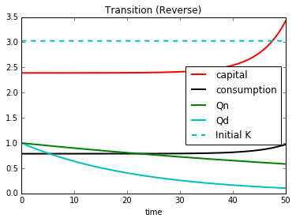

```
(1.1467640398740557, 2.07882479514846)
```

```python
years = 50
days  = 365
outyears = 5
A.transition_ss(years,days,outyears,True)
```

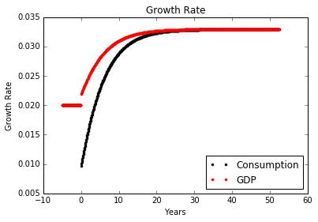

```python
GDP_growth_rate_a = ((A.GDP[1:]/A.GDP[:-1])) - 1
GDP_growth_rate_a[outyears*days-1]=GDP_growth_rate_a[outyears*days]
GDP_growth_rate_a[-outyears*days]=GDP_growth_rate_a[-outyears*days-1]

cap_growth_rate_a = ((A.Capseq[1:]/A.Capseq[:-1])) - 1
cap_disc_growth_rate_a = ((A.Kseq[1:]/A.Kseq[:-1])) - 1

con_growth_rate_a = ((A.Conseq[1:]/A.Conseq[:-1])) - 1
con_growth_rate_a[outyears*days-1]=con_growth_rate_a[outyears*days]
con_growth_rate_a[-outyears*days]=con_growth_rate_a[-outyears*days-1]

periods = len(con_growth_rate_a)
years = periods/365
ta = np.linspace(-5,(years-5),periods)

periods = len(con_growth_rate_a)
years = periods/365
t = np.linspace(-5,(years-5),periods)
plt.plot(ta[1::30],con_growth_rate_a[1::30]*365,'k.', label = "Consumption")
plt.plot(ta[1::30],GDP_growth_rate_a[1::30]*365,'r.', label = "GDP")
plt.xlabel("Years")
plt.ylabel("Growth Rate")
plt.legend(loc="best")
plt.title("Growth Rate")
plt.savefig("./SP/GDP_growth.pdf")
```

**Centrality of an industry and optimal innovation rates**

In this excercise, I am at addressing reviewer 1's point about impact of position of a sector in I-O structure on optimal R&D.

After calibrating my model, I perform camparative statics on $\alpha$, elasticity of output w.r.t. capital. In the network literature, higher $\alpha$ represents higher level of centrality for the investment goods producing industry. I solve for competitive equilibrium and social planner allocations for different values of $\alpha$.

```python
n_alp = 20
alpha_space = np.linspace(.24,.5,n_alp)
n_var = 15
n_var_ce = 13
def comparative_stats(cal):
    planner_cs= np.zeros((n_alp,n_var))
    competitive_cs= np.zeros((n_alp,n_var_ce))
    for index,alpha in enumerate(alpha_space):
        planner_cs[index,:] = cal.planner_cs(alpha)
        competitive_cs[index,:] = cal.competitive_cs(alpha)
    return planner_cs,competitive_cs
```

```python
def plot_cs(planner,competitive,filename):
    plt.plot(alpha_space,planner[:,4],'r--',linewidth=2,label=r'Planner $\tau_n$')
    plt.plot(alpha_space,competitive[:,2],'r',linewidth=2,label=r'Competitive $\tau_n$')
    plt.plot(alpha_space,planner[:,5],'k--',linewidth=2,label=r'Planner $\tau_d$')
    plt.plot(alpha_space,competitive[:,3],'k',linewidth=2,label=r'Competitive $\tau_d$')
    plt.xlabel(r'$\alpha$')
    plt.legend(loc='best')
    plt.xlim(xmin=.24)
    plt.savefig(filename)
```

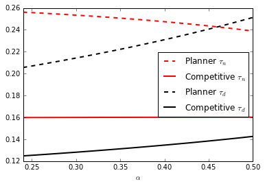

```python
planner_cs_A,competitive_cs_A = comparative_stats(A)
plot_cs(planner_cs_A,competitive_cs_A,'comparative_A_tau_alpha.pdf')
```

In the above graph, I plot innovations rates in each sector for each $\alpha$. Dashed lines are steady state innovation rates in the planner problem, solid lines are steady state innovation rates in the competitive equilibrium.

In the planner problem, as $\alpha$ increase, innovation rate in investment goods producing industry increases, while innovation rate in the consumption sector decreases. This result is intuitive. As the centrality of an industry increases, social planner allocates more resources towards that sector.

In the competitive equilibrium, as $\alpha$ increases, innovation rates in both industries increase. However, increase in consumption sector innovation is mild.

```python
def cal_cs_ratio(planner,competitive,filename):
    plt.plot(alpha_space,competitive[:,2]/planner[:,4],'r-.',linewidth=2,label=r'$\tau_n$')
    plt.plot(alpha_space,competitive[:,3]/planner[:,5],'k',linewidth=2,label=r'$\tau_d$')
    plt.xlabel(r'$\alpha$')
    plt.legend(loc='best')
    plt.xlim(xmin=.24)
    plt.savefig(filename)
```

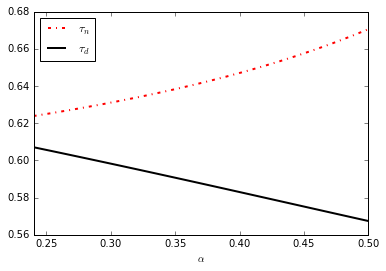

```python
cal_cs_ratio(planner_cs_A,competitive_cs_A,'comparative_A_tau_ratio_alpha.pdf')
```

Here, I plot competitve equilibrium innovaation rates relative to the social planner innovation rates. As $\alpha$ increases, investment good producing sector's innovation level in the competitive equilibrium diverges from the social planner level. On the other hand, consumption sector's innovation level in the competitive equilibrium converges to socially optimal level.

As the centrality of an industry increases, social planner allocates more innovative resources to that sector. However, since competitive equilibrium cannot internalize externalities, competitive equilibrium innovation rate does not increase as much in the investment sector. Similarly, as the centrality of investment sector increases, social planner allocates less resources to consumption sector. However, competitive equilibrium innovation rates are not affected much with the centrality of the other sector. Therefore, social planner innvoation rate in consumption sector approaches to CE innovation rates.

**Above excercise with an alternative calibration**

Now, repeat the above exercise with different calibration, where innovation functions of mthe sector are identical.

```python
# Alternative calibration, as if each sector has the identical parameters
B = innovation()
b,z,g_c = .096,.052,.02
targets= [b,z,g_c]
B.calibration(targets,alt_calib=True)
B.equilibrium()
```

```
array([ 0.02      ,  0.02      ,  0.16329708,  0.08778994,  0.05737465,
        0.10592243,  0.03084512,  0.05694483,  0.70898372,  0.18012574,
        4.08306156,  1.03735029,  5.12041185])
```

```python
# A different target set
# B = innovation()

# b_n,b_d,z_d,z_n,g_c,g_r = .095,.095,.05,.05,.02,0
# targets= [b_n,b_d,z_d,z_n,g_c,g_r]
# B.calibration(targets)

# B.equilibrium()
```

```python
B.planner_ss()
```

```
array([ 1.11457436,  0.89720348,  0.03081465,  0.02      ,  0.26123315,
        0.11569683,  0.06646162,  0.19477153,  0.029435  ,  0.08626182,
        0.53651882,  0.15813379,  3.35037041,  0.98748963,  4.33786004])
```

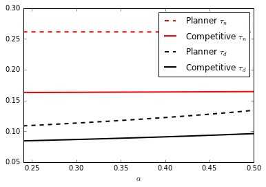

```python
planner_cs_B,competitive_cs_B = comparative_stats(B)
plot_cs(planner_cs_B,competitive_cs_B,'comparative_B_tau_alpha.pdf')
```

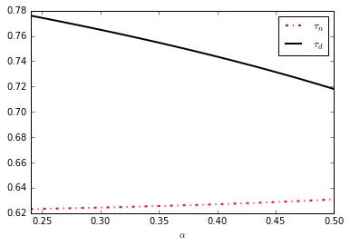

```python
cal_cs_ratio(planner_cs_B,competitive_cs_B,'comparative_B_tau_ratio_alpha.pdf')
```

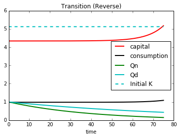

```
(1.1402366346686215, 2.5049871564645603)
```

```python
years = 75
days  = 365
outyears = 5
B.transition_ss(years,days,outyears,True)
```

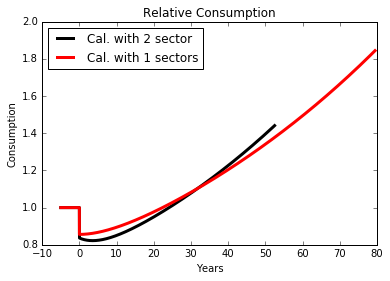

```python
con_growth_rate = ((B.Conseq[1:]/B.Conseq[:-1])) - 1
con_growth_rate[outyears*days-1]=con_growth_rate[outyears*days]
con_growth_rate[-outyears*days]=con_growth_rate[-outyears*days-1]

cap_growth_rate_b = ((B.Capseq[1:]/B.Capseq[:-1])) - 1
cap_disc_growth_rate_b = ((B.Kseq[1:]/B.Kseq[:-1])) - 1

GDP_growth_rate = ((B.GDP[1:]/B.GDP[:-1])) - 1
GDP_growth_rate[outyears*days-1]=GDP_growth_rate[outyears*days]
GDP_growth_rate[-outyears*days]=GDP_growth_rate[-outyears*days-1]

periods = len(A.Conseq)
years = periods/365
t = np.linspace(-5,(years-5),periods)

periods_b = len(B.Conseq)
years_b = periods_b/365
t_b = np.linspace(-5,(years_b-5),periods_b)

plt.plot(t,A.Conseq/A.Conseqalt,'k',linewidth=3,label="Cal. with 2 sector")
plt.plot(t_b,B.Conseq/B.Conseqalt,'r',linewidth=3,label="Cal. with 1 sectors")
plt.xlabel("Years")
plt.ylabel("Consumption")
plt.title("Relative Consumption")
plt.legend(loc='best')
plt.savefig("./SP/cons_rel.pdf")
```

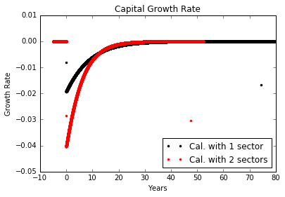

```python
periods = len(cap_growth_rate_b)
years = periods/365
t = np.linspace(-5,(years-5),periods)
periods_a = len(cap_growth_rate_a)
years_a = periods_a/365
ta = np.linspace(-5,(years_a-5),periods_a)
plt.plot(t,cap_disc_growth_rate_b*365,'k.',label="Cal. with 1 sector")
plt.plot(ta,cap_disc_growth_rate_a*365,'r.',label="Cal. with 2 sectors")
plt.xlabel("Years")
plt.ylabel("Growth Rate")
plt.title("Capital Growth Rate")
plt.legend(loc='best')
plt.savefig("./SP/cap_disc_growth_single_sector_cal.pdf")
```

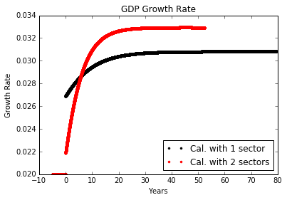

```python
periods = len(con_growth_rate)
years = periods/365
t = np.linspace(-5,(years-5),periods)
plt.plot(t,GDP_growth_rate*365,'k.',label="Cal. with 1 sector")
plt.plot(ta,GDP_growth_rate_a*365,'r.',label="Cal. with 2 sectors")
plt.xlabel("Years")
plt.ylabel("Growth Rate")
plt.title("GDP Growth Rate")
plt.legend(loc='best')
plt.savefig("./SP/GDP_growth_single_sector_cal.pdf")
```

```python
A.initiate()
```

```
3.0276445028615515
```

```python
#sub = (1-1/A.lambda_d,.82,.78,(.82-A.gamma)/(1-A.gamma),(.78-A.gamma)/(1-A.gamma))
sub = (0,.2,.2,0,0)
A.cost_spe_tax(sub)
```

[output not shown]

```python
years, days, outyears  = 72, 365, 5
nsub = 91
init_subs=(0,.2,.2,0,0)
upper_bound = .9
ns = np.linspace(0,upper_bound,nsub)
ds = np.linspace(0,upper_bound,nsub)
welfare4    = np.zeros((nsub,nsub))
welfare4_10 = np.zeros((nsub,nsub))
welfare4_20 = np.zeros((nsub,nsub))
welfare4_ss = np.zeros((nsub,nsub))
for index,n in enumerate(ns):
    print ('Outer loop =', index)
    n_ent = (n-A.gamma)/(1-A.gamma)
    for index2,d in enumerate(ds):
        #print ('Inner loop =', index2)
        d_ent = (d-A.gamma)/(1-A.gamma)
        subs = (1-1/A.lambda_d,n,d,n_ent,d_ent)
        welfare4[index,index2],welfare4_10[index,index2],welfare4_20[index,index2],welfare4_ss[index,index2] = A.transition(init_subs,subs,years,days,outyears)
```

[output not shown]

[output cut: 36 more lines]

[output not shown]

```python
np.savetxt("welfare_10.csv", welfare4_10, delimiter=",")
np.savetxt("welfare_20.csv", welfare4_20, delimiter=",")
np.savetxt("welfare_40.csv", welfare4, delimiter=",")
```

```python
welfare4 = np.loadtxt("welfare_convex_entry_inc_inv_46_diff_call.csv",delimiter=",")
```

```python
nsub = 91
lower_bound = 0
upper_bound = .9
ns = np.linspace(lower_bound,upper_bound,nsub)
ds = np.linspace(lower_bound,upper_bound,nsub)
tax_cost = A.costs(nsub,lower_bound,upper_bound,both=True,differ=True,inv_sub=True)
```

```python
np.savetxt("./cost.csv", tax_cost, delimiter=",")
```

```python
tax_cost = np.loadtxt("tax_cost_all_46.csv",delimiter=",")
```

```python
for i in range(nsub):
    for j in range(nsub):
        if not (A.correct[i,j]):
            welfare4[i,j]=.9
```

```python
opt_wel=np.max(welfare4)
a = np.argwhere(welfare4==opt_wel)
print ('Con Subsidy', ns[a[0,0]],'Inv Subsidy', ds[a[0,1]],'Welfare',opt_wel)
```

```
Con Subsidy 0.82 Inv Subsidy 0.78 Welfare 1.14665120431
```

```python
%matplotlib inline
CS = plt.contourf(ds, ns, welfare4, 15,
                  cmap=plt.cm.bone,
                  origin='upper')

plt.title('Welfare Gain',fontsize=14)
plt.xlabel('Investment Sector Subsidy',fontsize=14)
plt.ylabel('Consumption Sector Subsidy',fontsize=14)

plt.plot(ds[a[0,1]],ns[a[0,0]],marker='o', color='r', ls='')
txt = '{0:.3f}'.format(welfare4[a[0,0],a[0,1]])
plt.annotate(txt,(ds[a[0,1]],ns[a[0,0]]),horizontalalignment='left',
             verticalalignment='bottom')

# Make a colorbar for the ContourSet returned by the contourf call.
cbar = plt.colorbar(CS)
cbar.ax.set_ylabel('Welfare Gain',fontsize=14)


CS2 = plt.contour(ds, ns, tax_cost,[.04,.05,.06,.07,.08,.1,.12,.14,.2,.25])
plt.clabel(CS2, inline=1, fontsize=10)

plt.savefig("welfare-cost.pdf",bbox_inches='tight')
plt.close()
```

```python
B.initiate()
years, days, outyears  = 72, 365, 5
nsub = 91
init_subs=(0,.2,.2,0,0)
upper_bound = .9
ns = np.linspace(0,upper_bound,nsub)
ds = np.linspace(0,upper_bound,nsub)
welfare4B    = np.zeros((nsub,nsub))
welfare4_10B = np.zeros((nsub,nsub))
welfare4_20B = np.zeros((nsub,nsub))
welfare4_ssB = np.zeros((nsub,nsub))
for index,n in enumerate(ns):
    print ('Outer loop =', index)
    n_ent = (n-A.gamma)/(1-A.gamma)
    for index2,d in enumerate(ds):
        #print ('Inner loop =', index2)
        d_ent = (d-A.gamma)/(1-A.gamma)
        subs = (1-1/A.lambda_d,n,d,n_ent,d_ent)
        welfare4B[index,index2],welfare4_10B[index,index2],welfare4_20B[index,index2],welfare4_ssB[index,index2] = B.transition(init_subs,subs,years,days,outyears)
```

```
Outer loop = 0
Increasing the transition years
```

[output not shown]

[output cut: 3680 more lines]

[output not shown]

```python
np.savetxt("welfare_10B.csv", welfare4_10B, delimiter=",")
np.savetxt("welfare_20B.csv", welfare4_20B, delimiter=",")
np.savetxt("welfare_40B.csv", welfare4B, delimiter=",")
```

```python
nsub = 91
lower_bound = 0
upper_bound = .9
ns = np.linspace(lower_bound,upper_bound,nsub)
ds = np.linspace(lower_bound,upper_bound,nsub)
tax_cost = B.costs(nsub,lower_bound,upper_bound,both=True,differ=True,inv_sub=True)
```

```python
np.savetxt("./costB.csv", tax_cost, delimiter=",")
```

```python
for i in range(nsub):
    for j in range(nsub):
        if not (A.correct[i,j]):
            welfare4B[i,j]=.9
```

```python
opt_welB=np.max(welfare4B)
a = np.argwhere(welfare4B==opt_welB)
print ('Con Subsidy', ns[a[0,0]],'Inv Subsidy', ds[a[0,1]],'Welfare',opt_wel)
```

```
Con Subsidy 0.83 Inv Subsidy 0.63 Welfare 1.14665120431
```

```python
%matplotlib inline
CS = plt.contourf(ds, ns, welfare4B, 15,
                  cmap=plt.cm.bone,
                  origin='upper')

plt.title('Welfare Gain',fontsize=14)
plt.xlabel('Investment Sector Subsidy',fontsize=14)
plt.ylabel('Consumption Sector Subsidy',fontsize=14)

plt.plot(ds[a[0,1]],ns[a[0,0]],marker='o', color='r', ls='')
txt = '{0:.3f}'.format(welfare4[a[0,0],a[0,1]])
plt.annotate(txt,(ds[a[0,1]],ns[a[0,0]]),horizontalalignment='left',
             verticalalignment='bottom')

# Make a colorbar for the ContourSet returned by the contourf call.
cbar = plt.colorbar(CS)
cbar.ax.set_ylabel('Welfare Gain',fontsize=14)


CS2 = plt.contour(ds, ns, tax_cost,[.04,.05,.06,.07,.08,.1,.12,.14,.2,.25])
plt.clabel(CS2, inline=1, fontsize=10)

plt.savefig("welfare-costB.pdf",bbox_inches='tight')
plt.close()
```

```python
cost_points = 91
optimal_subsidy = np.zeros((2,cost_points))
cost_range = np.linspace(0.052,.2,cost_points)
costs = np.zeros(91)
welfares = np.zeros(91)
x_subs = np.zeros(91)
c_subs = np.zeros(91)
for i in range(cost_points):
    #cost = tax_cost[i,i]
    cost = cost_range[i]
    costs[i] = cost
    subsidies = [tax_cost <= cost]
    opt_welfare = np.max(welfare4B[subsidies])
    welfares[i]=opt_welfare
    opt_subsidy = np.argwhere(welfare4B==opt_welfare)
    optimal_subsidy[:,i]=(ns[opt_subsidy[0,0]],ds[opt_subsidy[0,1]])
    x_subs[i]=ds[opt_subsidy[0,1]]
    c_subs[i]=ns[opt_subsidy[0,0]]
    print ('Uniform Subsidy','{0:.2f}'.format(ns[i]) ,
           'Welfare','{0:.4f}'.format(welfare4B[i,i]), 'Cost', '{0:.3f}'.format(cost),
           'Inv Subsidy' , '{0:.2f}'.format(ds[opt_subsidy[0,1]]),'Con Subsidy' ,'{0:.2f}'.format(ns[opt_subsidy[0,0]]),
           'Optimal Welfare', '{0:.4f}'.format(opt_welfare))
```

```
Uniform Subsidy 0.00 Welfare 0.9506 Cost 0.052 Inv Subsidy 0.02 Con Subsidy 0.44 Optimal Welfare 1.0264
Uniform Subsidy 0.01 Welfare 0.9520 Cost 0.054 Inv Subsidy 0.05 Con Subsidy 0.45 Optimal Welfare 1.0292
Uniform Subsidy 0.02 Welfare 0.9535 Cost 0.055 Inv Subsidy 0.08 Con Subsidy 0.46 Optimal Welfare 1.0321
Uniform Subsidy 0.03 Welfare 0.9549 Cost 0.057 Inv Subsidy 0.09 Con Subsidy 0.47 Optimal Welfare 1.0347
Uniform Subsidy 0.04 Welfare 0.9564 Cost 0.059 Inv Subsidy 0.10 Con Subsidy 0.48 Optimal Welfare 1.0373
Uniform Subsidy 0.05 Welfare 0.9579 Cost 0.060 Inv Subsidy 0.11 Con Subsidy 0.49 Optimal Welfare 1.0400
Uniform Subsidy 0.06 Welfare 0.9594 Cost 0.062 Inv Subsidy 0.11 Con Subsidy 0.50 Optimal Welfare 1.0425
Uniform Subsidy 0.07 Welfare 0.9610 Cost 0.064 Inv Subsidy 0.10 Con Subsidy 0.51 Optimal Welfare 1.0449
Uniform Subsidy 0.08 Welfare 0.9626 Cost 0.065 Inv Subsidy 0.09 Con Subsidy 0.52 Optimal Welfare 1.0473
Uniform Subsidy 0.09 Welfare 0.9641 Cost 0.067 Inv Subsidy 0.22 Con Subsidy 0.52 Optimal Welfare 1.0497
Uniform Subsidy 0.10 Welfare 0.9657 Cost 0.068 Inv Subsidy 0.20 Con Subsidy 0.53 Optimal Welfare 1.0519
Uniform Subsidy 0.11 Welfare 0.9673 Cost 0.070 Inv Subsidy 0.18 Con Subsidy 0.54 Optimal Welfare 1.0543
Uniform Subsidy 0.12 Welfare 0.9690 Cost 0.072 Inv Subsidy 0.15 Con Subsidy 0.55 Optimal Welfare 1.0564
Uniform Subsidy 0.13 Welfare 0.9706 Cost 0.073 Inv Subsidy 0.26 Con Subsidy 0.55 Optimal Welfare 1.0585
Uniform Subsidy 0.14 Welfare 0.9723 Cost 0.075 Inv Subsidy 0.23 Con Subsidy 0.56 Optimal Welfare 1.0606
Uniform Subsidy 0.15 Welfare 0.9740 Cost 0.077 Inv Subsidy 0.19 Con Subsidy 0.57 Optimal Welfare 1.0627
Uniform Subsidy 0.16 Welfare 0.9757 Cost 0.078 Inv Subsidy 0.29 Con Subsidy 0.57 Optimal Welfare 1.0646
Uniform Subsidy 0.17 Welfare 0.9775 Cost 0.080 Inv Subsidy 0.25 Con Subsidy 0.58 Optimal Welfare 1.0666
Uniform Subsidy 0.18 Welfare 0.9792 Cost 0.082 Inv Subsidy 0.20 Con Subsidy 0.59 Optimal Welfare 1.0685
Uniform Subsidy 0.19 Welfare 0.9810 Cost 0.083 Inv Subsidy 0.29 Con Subsidy 0.59 Optimal Welfare 1.0703
Uniform Subsidy 0.20 Welfare 0.9828 Cost 0.085 Inv Subsidy 0.24 Con Subsidy 0.60 Optimal Welfare 1.0722
Uniform Subsidy 0.21 Welfare 0.9846 Cost 0.087 Inv Subsidy 0.33 Con Subsidy 0.60 Optimal Welfare 1.0739
Uniform Subsidy 0.22 Welfare 0.9865 Cost 0.088 Inv Subsidy 0.27 Con Subsidy 0.61 Optimal Welfare 1.0757
Uniform Subsidy 0.23 Welfare 0.9884 Cost 0.090 Inv Subsidy 0.35 Con Subsidy 0.61 Optimal Welfare 1.0772
Uniform Subsidy 0.24 Welfare 0.9903 Cost 0.091 Inv Subsidy 0.29 Con Subsidy 0.62 Optimal Welfare 1.0791
Uniform Subsidy 0.25 Welfare 0.9922 Cost 0.093 Inv Subsidy 0.37 Con Subsidy 0.62 Optimal Welfare 1.0806
Uniform Subsidy 0.26 Welfare 0.9941 Cost 0.095 Inv Subsidy 0.30 Con Subsidy 0.63 Optimal Welfare 1.0822
Uniform Subsidy 0.27 Welfare 0.9961 Cost 0.096 Inv Subsidy 0.37 Con Subsidy 0.63 Optimal Welfare 1.0836
Uniform Subsidy 0.28 Welfare 0.9981 Cost 0.098 Inv Subsidy 0.31 Con Subsidy 0.64 Optimal Welfare 1.0855
Uniform Subsidy 0.29 Welfare 1.0001 Cost 0.100 Inv Subsidy 0.38 Con Subsidy 0.64 Optimal Welfare 1.0868
Uniform Subsidy 0.30 Welfare 1.0022 Cost 0.101 Inv Subsidy 0.30 Con Subsidy 0.65 Optimal Welfare 1.0883
Uniform Subsidy 0.31 Welfare 1.0043 Cost 0.103 Inv Subsidy 0.37 Con Subsidy 0.65 Optimal Welfare 1.0896
Uniform Subsidy 0.32 Welfare 1.0064 Cost 0.105 Inv Subsidy 0.28 Con Subsidy 0.66 Optimal Welfare 1.0910
Uniform Subsidy 0.33 Welfare 1.0085 Cost 0.106 Inv Subsidy 0.36 Con Subsidy 0.66 Optimal Welfare 1.0925
Uniform Subsidy 0.34 Welfare 1.0107 Cost 0.108 Inv Subsidy 0.42 Con Subsidy 0.66 Optimal Welfare 1.0936
Uniform Subsidy 0.35 Welfare 1.0129 Cost 0.110 Inv Subsidy 0.33 Con Subsidy 0.67 Optimal Welfare 1.0950
Uniform Subsidy 0.36 Welfare 1.0151 Cost 0.111 Inv Subsidy 0.40 Con Subsidy 0.67 Optimal Welfare 1.0963
Uniform Subsidy 0.37 Welfare 1.0173 Cost 0.113 Inv Subsidy 0.29 Con Subsidy 0.68 Optimal Welfare 1.0973
Uniform Subsidy 0.38 Welfare 1.0196 Cost 0.114 Inv Subsidy 0.37 Con Subsidy 0.68 Optimal Welfare 1.0989
Uniform Subsidy 0.39 Welfare 1.0219 Cost 0.116 Inv Subsidy 0.43 Con Subsidy 0.68 Optimal Welfare 1.1000
```

[output cut: 36 more lines]

```
Uniform Subsidy 0.76 Welfare 1.1195 Cost 0.177 Inv Subsidy 0.59 Con Subsidy 0.77 Optimal Welfare 1.1280
Uniform Subsidy 0.77 Welfare 1.1210 Cost 0.179 Inv Subsidy 0.43 Con Subsidy 0.78 Optimal Welfare 1.1281
Uniform Subsidy 0.78 Welfare 1.1222 Cost 0.180 Inv Subsidy 0.48 Con Subsidy 0.78 Optimal Welfare 1.1290
Uniform Subsidy 0.79 Welfare 1.1229 Cost 0.182 Inv Subsidy 0.52 Con Subsidy 0.78 Optimal Welfare 1.1297
Uniform Subsidy 0.80 Welfare 1.1232 Cost 0.184 Inv Subsidy 0.55 Con Subsidy 0.78 Optimal Welfare 1.1300
Uniform Subsidy 0.81 Welfare 1.1228 Cost 0.185 Inv Subsidy 0.58 Con Subsidy 0.78 Optimal Welfare 1.1303
Uniform Subsidy 0.82 Welfare 1.1218 Cost 0.187 Inv Subsidy 0.60 Con Subsidy 0.78 Optimal Welfare 1.1304
Uniform Subsidy 0.83 Welfare 1.1198 Cost 0.188 Inv Subsidy 0.61 Con Subsidy 0.78 Optimal Welfare 1.1304
Uniform Subsidy 0.84 Welfare 1.1169 Cost 0.190 Inv Subsidy 0.48 Con Subsidy 0.79 Optimal Welfare 1.1311
Uniform Subsidy 0.85 Welfare 1.1126 Cost 0.192 Inv Subsidy 0.52 Con Subsidy 0.79 Optimal Welfare 1.1317
Uniform Subsidy 0.86 Welfare 1.1068 Cost 0.193 Inv Subsidy 0.56 Con Subsidy 0.79 Optimal Welfare 1.1322
Uniform Subsidy 0.87 Welfare 1.0991 Cost 0.195 Inv Subsidy 0.58 Con Subsidy 0.79 Optimal Welfare 1.1323
Uniform Subsidy 0.88 Welfare 1.0890 Cost 0.197 Inv Subsidy 0.61 Con Subsidy 0.79 Optimal Welfare 1.1325
Uniform Subsidy 0.89 Welfare 1.0761 Cost 0.198 Inv Subsidy 0.61 Con Subsidy 0.79 Optimal Welfare 1.1325
Uniform Subsidy 0.90 Welfare 1.0594 Cost 0.200 Inv Subsidy 0.61 Con Subsidy 0.79 Optimal Welfare 1.1325
```

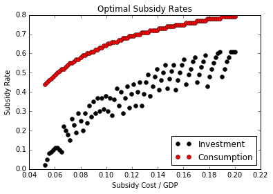

```python
plt.plot(costs,x_subs,'ko',label='Investment')
plt.plot(costs,c_subs,'ro',label='Consumption')
plt.xlabel('Subsidy Cost / GDP')
plt.ylabel('Subsidy Rate')
plt.title('Optimal Subsidy Rates')
plt.legend(loc='lower right')
plt.savefig('optimal_sub.pdf')
```

[figure not shown]

```python
plt.plot(costs,welfares-1,'k',linewidth=3)
plt.xlabel('Subsidy Cost / GDP')
plt.ylabel('Welfare Gain')
plt.title('Consumption Equivalent Welfare Gain')
#plt.savefig('cost_welfaregain.pdf')
```

```python
x_subs
```

[output not shown]

```python
tax_cost_ratios = np.zeros(len(costs))
for index,cost in enumerate(costs):
    subs = 1-1/A.lambda_d, c_subs[index],x_subs[index],(c_subs[index]-A.gamma)/(1-A.gamma),(x_subs[index]-A.gamma)/(1-A.gamma)
    tax_cost = A.cost_spe_tax(subs)
    tax_cost_ratios[index]=tax_cost[2]/tax_cost[3]
```

[figure not shown]

```python
plt.plot(tax_cost_ratios[6:])
```

```python
optimal_subsidy = np.zeros((2,nsub))
for i in range(nsub):
    cost = tax_cost[i,i]
    subsidies = [tax_cost <= cost]
    opt_welfare = np.max(welfare4[subsidies])
    opt_subsidy = np.argwhere(welfare4==opt_welfare)
    optimal_subsidy[:,i]=(ns[opt_subsidy[0,0]],ds[opt_subsidy[0,1]])
    print ('Uniform Subsidy','{0:.2f}'.format(ns[i]) ,
           'Welfare','{0:.4f}'.format(welfare4[i,i]), 'Cost', '{0:.3f}'.format(cost),
           'Inv Subsidy' , '{0:.2f}'.format(ds[opt_subsidy[0,1]]),'Con Subsidy' ,'{0:.2f}'.format(ns[opt_subsidy[0,0]]),
           'Optimal Welfare', '{0:.4f}'.format(opt_welfare))
```

[output not shown]

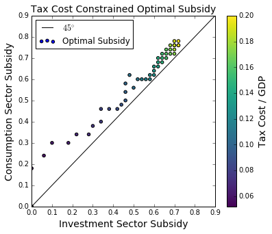

```python
plt.figure(figsize=(6,5))
plt.xlim(0,.9)
plt.ylim(0,.9)
t= cost_range
CS = plt.scatter(optimal_subsidy[1,:], optimal_subsidy[0,:], c=t, cmap='viridis',label='Optimal Subsidy')
cbar = plt.colorbar(CS)
cbar.ax.set_ylabel('Tax Cost / GDP',fontsize=14)
#plt.plot(optimal_subsidy[1,:],optimal_subsidy[0,:],'ro',label='Optimal Subsidy')
xlist = [x for x in np.linspace(0,.9,91)]
plt.plot(xlist,xlist,'k',label=r'$45^{\circ}$')
plt.xlabel('Investment Sector Subsidy',fontsize=14)
plt.ylabel('Consumption Sector Subsidy',fontsize=14)
plt.title('Tax Cost Constrained Optimal Subsidy',fontsize=14)
plt.legend(loc='upper left')
plt.savefig('constrained_optimal_subsidy.pdf')
```

```python
sub = (0,.2,.2,0,0)
cost = .43/.26*A.cost_spe_tax(sub)
subsidies = [tax_cost <= cost[1]]
opt_welfare = np.max(welfare4[subsidies])
opt_subsidy = np.argwhere(welfare4==opt_welfare)
optimal_subsidy=(ns[opt_subsidy[0,0]],ds[opt_subsidy[0,1]])
print ('Uniform Subsidy','{0:.2f}'.format(ns[i]) ,
           'Cost', '{0:.3f}'.format(cost[1]),
           'Inv Subsidy' , '{0:.2f}'.format(ds[opt_subsidy[0,1]]),'Con Subsidy' ,'{0:.2f}'.format(ns[opt_subsidy[0,0]]),
           'Optimal Welfare', '{0:.4f}'.format(opt_welfare))
```

```
Uniform Subsidy 0.90 Cost 0.010 Inv Subsidy 0.38 Con Subsidy 0.38 Optimal Welfare 1.0497
```

```
1.04043814656
1.04043814656
1.04043814655
1.04043809712
1.04043809712
1.0404380477
1.0404380477
1.04043799829
1.04043799829
1.04043750482
1.04043750482
1.04043701249
1.04043701249
1.04043652128
1.04043652128
1.04043603117
1.04043603117
1.04043118738
1.04043118739
1.04042643692
1.04042643691
1.04042176467
1.04042176465
1.04041715599
1.04041715597
1.0404125967
1.04041259668
1.04039351783
1.04039351612
1.0403740897
1.04037408794
1.04035336895
1.04035337556
1.04033045298
1.04033045542
1.04030437568
1.04030437639
1.04027411361
1.04027411424
1.0402343759
```

[output cut: 72 more lines]

```
0.969241121713
0.961867389923
0.961867390508
0.953666618509
0.95366662233
0.944530807104
0.944530817084
0.934333939878
0.934333958927
0.922927894786
0.922927927944
0.910137093663
0.910137148983
0.912744394771
0.912744421181
```

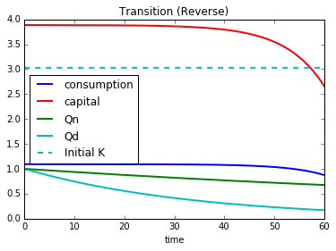

```
Welfare Gain 1.0223482928
Welfare Gain SS 1.11528197066
1.0489694449
1.04896944489
1.04896944488
1.04896938577
1.04896938577
1.04896932667
1.04896932667
1.04896926758
1.04896926758
1.04896867748
1.04896867748
1.04896808874
1.04896808874
1.04896750135
1.04896750135
1.04896691528
1.04896691528
1.04896112325
1.04896112326
1.0489554428
1.04895544279
1.04894985542
1.04894985539
1.04894434314
1.04894434312
1.04893888859
1.04893888857
1.04891261991
1.04891261642
1.04888548018
1.04888547657
1.04885570036
1.04885571584
1.04882156035
1.04882156632
1.04878114299
1.04878114389
1.04873232909
```

[output cut: 76 more lines]

```
0.926349678501
0.913496156372
0.913496180052
0.915823994802
0.915824006742
0.904269718002
0.904269727054
0.891559838334
0.891559862616
0.877545509401
0.877545542125
0.862050543508
0.862050595763
0.865199665128
0.865199689944
```

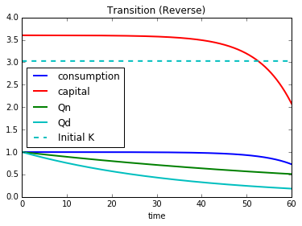

```
Welfare Gain 1.0779063842
Welfare Gain SS 1.43785246637
0.952409949711
0.952409949723
0.952409949734
0.952410066684
0.952410066684
0.952410183676
0.952410183676
0.95241030071
0.95241030071
0.952411473359
0.95241147336
0.952412650241
0.952412650241
0.95241383139
0.95241383139
0.952415016847
0.952415016847
0.95242711663
0.952427116639
0.952439689099
0.952439689143
0.952452773121
0.952452773192
0.95246640833
0.952466408401
0.952480635256
0.952480635324
0.952516789887
0.952516790823
0.952557050466
0.952557051126
0.952602044845
0.952602042933
0.952652454267
0.952652454039
0.952709044865
0.952709045049
0.952772662852
```

[output cut: 136 more lines]

```
1.64924646591
1.64438200688
1.64438186808
1.66287977186
1.66287969863
1.68130499259
1.68130468908
1.67762810048
1.6776279591
1.69230321564
1.69230313403
1.7068738257
1.70687348016
1.70383083666
1.70383068305
```

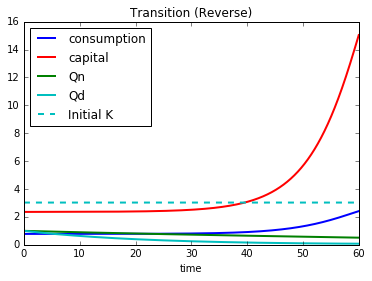

```
Welfare Gain 1.14665888376
Welfare Gain SS 1.88007907603
```

```python
years, days, outyears  =60, 365, 5
init_subs=(0,.2,.2,0,0)
n = .2
d = .2
subs = (1-1/A.lambda_d,n,d,0,0)
[long,short,medium,ss]=A.transition(init_subs,subs,years,days,outyears,graph=True)
cons_invs = A.Conseq
utility_invs = A.utility
print ('Welfare Gain', long)
print ('Welfare Gain SS', ss)

n = .82
n_e = (n-A.gamma)/(1-A.gamma)
subs = (1-1/A.lambda_d,n,d,n_e,0)
[long,short,medium,ss]=A.transition(init_subs,subs,years,days,outyears,graph=True)
cons_invs_cons = A.Conseq
utility_invs_cons = A.utility
print ('Welfare Gain', long)
print ('Welfare Gain SS', ss)

d = .78
d_e = (d-A.gamma)/(1-A.gamma)
subs = (1-1/A.lambda_d,n,d,n_e,d_e)
[long,short,medium,ss]=A.transition(init_subs,subs,years,days,outyears,graph=True)
cons_invs_cons_inv = A.Conseq
utility_invs_cons_inv = A.utility
print ('Welfare Gain', long)
print ('Welfare Gain SS', ss)
```

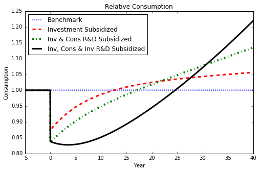

```python
periods_1 = len(cons_invs)
years1 = periods_1/365
periods_2 = len(cons_invs_cons)
years2 = periods_2/365
periods_3 = len(cons_invs_cons_inv)
years3 = periods_3/365
periods=min(periods_1,periods_2,periods_3)
end = int(2/3*periods)
years = min(years1,years2,years3)
t = np.linspace(-5,(years-5),periods)
plt.figure(figsize=(8,5))
plt.plot(t[:end],A.Conseqalt[:end]/A.Conseqalt[:end],'b:',linewidth=3,label="Benchmark")
plt.plot(t[:end],cons_invs[:end]/A.Conseqalt[:end],'r--',linewidth=3,label="Investment Subsidized")
plt.plot(t[:end],cons_invs_cons[:end]/A.Conseqalt[:end],'g-.',linewidth=4,label="Inv & Cons R&D Subsidized")
plt.plot(t[:end],cons_invs_cons_inv[:end]/A.Conseqalt[:end],'k',linewidth=3,label="Inv, Cons & Inv R&D Subsidized")
plt.xlabel('Year')
plt.ylabel('Consumption')
plt.title('Relative Consumption')
plt.legend(loc='upper left')
plt.ylim(.8,1.25)
plt.xlim(-5,40)
plt.savefig('cons_sequences_rel4.pdf',bbox_inches='tight')
```

[figure not shown]

[output not shown]

```python
years, days, outyears  =45, 365, 5
init_subs=(0,.2,.2,0,0)
n = .82
n_e = (n-A.gamma)/(1-A.gamma)
d = .78
d_e = (d-A.gamma)/(1-A.gamma)
subs = (1-1/A.lambda_d,n,d,n_e,d_e)
[long,short,medium,ss]=A.transition(init_subs,subs,years,days,outyears,graph=True)
cons_invs_cons_inv = A.Conseq
utility_invs_cons_inv = A.utility
print ('Welfare Gain', long)
print ('Welfare Gain SS', ss)
```

```python
con_growth_rate_a = ((A.Conseq[1:]/A.Conseq[:-1])) - 1
con_growth_rate_a[outyears*days-1]=con_growth_rate_a[outyears*days]
con_growth_rate_a[-outyears*days]=con_growth_rate_a[-outyears*days-1]
```

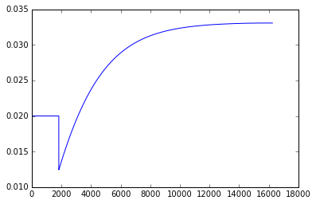

```python
plt.plot(con_growth_rate_a[:-outyears*days*5]*365)
```

```python
import pandas.io.data as web
import datetime as dt
start, end = dt.datetime(2000,1,1), dt.datetime(2016,12,31)
consumption = web.DataReader('PCEC96', 'fred', start, end)
invest_price = web.DataReader('PIRIC', 'fred', start, end)
consumption = consumption.resample('A',how='mean')
invest_price = invest_price.resample('A',how='mean')
consumption_disc = consumption/consumption.ix[0]
```

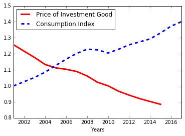

```python
%matplotlib inline
plt.plot(invest_price,'r',linewidth=3,label='Price of Investment Good')
plt.plot(consumption_disc,'b--',linewidth=3,label='Consumption Index')
plt.legend(loc='best')
plt.xlabel('Years')
#plt.title('Relative Price of Quality Adjusted Investment Good')
plt.savefig('consumption_investment.pdf')
```

```python
years, days, outyears  = 72, 365, 5
nsub = 46
init_subs=(0,.2,.2,0,0)
upper_bound = .9
ns = np.linspace(0,upper_bound,nsub)
ds = np.linspace(0,upper_bound,nsub)
welfare    = np.zeros((nsub,nsub))
welfare_10 = np.zeros((nsub,nsub))
welfare_20 = np.zeros((nsub,nsub))
for index,n in enumerate(ns):
    print ('Outer loop =', index)
    for index2,d in enumerate(ds):
        #print ('Inner loop =', index2)
        subs = (0,n,d,0,0)
        welfare[index,index2],welfare_10[index,index2],welfare_20[index,index2]=A.transition(init_subs,subs,years,days,outyears)
```

```
Outer loop = 0
Outer loop = 1
Outer loop = 2
Outer loop = 3
Outer loop = 4
Outer loop = 5
Outer loop = 6
Outer loop = 7
Outer loop = 8
Outer loop = 9
Outer loop = 10
Outer loop = 11
Outer loop = 12
Outer loop = 13
Outer loop = 14
Outer loop = 15
Outer loop = 16
Outer loop = 17
Outer loop = 18
Outer loop = 19
Outer loop = 20
Outer loop = 21
Outer loop = 22
Outer loop = 23
Outer loop = 24
Outer loop = 25
Outer loop = 26
Outer loop = 27
Outer loop = 28
Outer loop = 29
Outer loop = 30
Outer loop = 31
Outer loop = 32
Outer loop = 33
Outer loop = 34
Outer loop = 35
Outer loop = 36
Outer loop = 37
Outer loop = 38
Outer loop = 39
Outer loop = 40
Outer loop = 41
Outer loop = 42
Outer loop = 43
Outer loop = 44
Outer loop = 45
```

```python
np.savetxt("welfare_convex_inc_ncg-46_diff_call.csv", welfare, delimiter=",")
```

```python
nsub = 46
upper_bound = .9
ns = np.linspace(0,upper_bound,nsub)
ds = np.linspace(0,upper_bound,nsub)
tax_cost_ = A.costs(nsub,upper_bound,both=False,differ=True,inv_sub=False)
```

```python
opt_wel=np.max(welfare)
a = np.argwhere(welfare==opt_wel)
print ('Con Subsidy', ns[a[0,0]],'Inv Subsidy', ds[a[0,1]],'Welfare',opt_wel)
```

```
Con Subsidy 0.76 Inv Subsidy 0.78 Welfare 1.1148088325
```

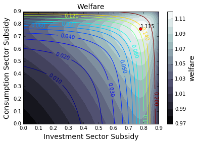

```python
%matplotlib inline
CS = plt.contourf(ds, ns, welfare, 15,
                  cmap=plt.cm.bone,
                  origin='upper')

plt.title('Welfare',fontsize=14)
plt.xlabel('Investment Sector Subsidy',fontsize=14)
plt.ylabel('Consumption Sector Subsidy',fontsize=14)

plt.plot(ds[a[0,1]],ns[a[0,0]],marker='o', color='r', ls='')
txt = '{0:.3f}'.format(welfare[a[0,0],a[0,1]])
plt.annotate(txt,(ds[a[0,1]],ns[a[0,0]]),horizontalalignment='left',
             verticalalignment='bottom')

# Make a colorbar for the ContourSet returned by the contourf call.
cbar = plt.colorbar(CS)
cbar.ax.set_ylabel('welfare',fontsize=14)


CS2 = plt.contour(ds, ns, tax_cost_,[.01,.02,.03,.04,.05,.06,.07,.08,.1,.12,.14,.2])
plt.clabel(CS2, inline=1, fontsize=10)

plt.savefig("welfare-trans-convex_inc-46_diff_call.pdf",bbox_inches='tight')
#plt.close()
```

```python
cost_points = 91
optimal_subsidy = np.zeros((2,cost_points))
cost_range = np.linspace(0,.2,cost_points)
for i in range(cost_points):
    #cost = tax_cost[i,i]
    cost = cost_range[i]
    subsidies = [tax_cost_ <= cost]
    opt_welfare = np.max(welfare[subsidies])
    opt_subsidy = np.argwhere(welfare==opt_welfare)
    optimal_subsidy[:,i]=(ns[opt_subsidy[0,0]],ds[opt_subsidy[0,1]])
    print ('Cost', '{0:.3f}'.format(cost),
           'Inv Subsidy' , '{0:.2f}'.format(ds[opt_subsidy[0,1]]),'Con Subsidy' ,'{0:.2f}'.format(ns[opt_subsidy[0,0]]),
           'Optimal Welfare', '{0:.4f}'.format(opt_welfare))
```

```
Cost 0.000 Inv Subsidy 0.00 Con Subsidy 0.00 Optimal Welfare 0.9730
Cost 0.002 Inv Subsidy 0.06 Con Subsidy 0.12 Optimal Welfare 0.9836
Cost 0.004 Inv Subsidy 0.14 Con Subsidy 0.18 Optimal Welfare 0.9935
Cost 0.007 Inv Subsidy 0.22 Con Subsidy 0.20 Optimal Welfare 1.0018
Cost 0.009 Inv Subsidy 0.26 Con Subsidy 0.26 Optimal Welfare 1.0096
Cost 0.011 Inv Subsidy 0.30 Con Subsidy 0.30 Optimal Welfare 1.0165
Cost 0.013 Inv Subsidy 0.30 Con Subsidy 0.38 Optimal Welfare 1.0225
Cost 0.016 Inv Subsidy 0.34 Con Subsidy 0.40 Optimal Welfare 1.0285
Cost 0.018 Inv Subsidy 0.40 Con Subsidy 0.38 Optimal Welfare 1.0339
Cost 0.020 Inv Subsidy 0.44 Con Subsidy 0.38 Optimal Welfare 1.0390
Cost 0.022 Inv Subsidy 0.44 Con Subsidy 0.44 Optimal Welfare 1.0440
Cost 0.024 Inv Subsidy 0.46 Con Subsidy 0.46 Optimal Welfare 1.0483
Cost 0.027 Inv Subsidy 0.50 Con Subsidy 0.44 Optimal Welfare 1.0520
Cost 0.029 Inv Subsidy 0.50 Con Subsidy 0.48 Optimal Welfare 1.0556
Cost 0.031 Inv Subsidy 0.50 Con Subsidy 0.52 Optimal Welfare 1.0593
Cost 0.033 Inv Subsidy 0.54 Con Subsidy 0.50 Optimal Welfare 1.0632
Cost 0.036 Inv Subsidy 0.56 Con Subsidy 0.50 Optimal Welfare 1.0661
Cost 0.038 Inv Subsidy 0.54 Con Subsidy 0.56 Optimal Welfare 1.0688
Cost 0.040 Inv Subsidy 0.56 Con Subsidy 0.56 Optimal Welfare 1.0718
Cost 0.042 Inv Subsidy 0.58 Con Subsidy 0.56 Optimal Welfare 1.0748
Cost 0.044 Inv Subsidy 0.58 Con Subsidy 0.58 Optimal Welfare 1.0767
Cost 0.047 Inv Subsidy 0.60 Con Subsidy 0.58 Optimal Welfare 1.0798
Cost 0.049 Inv Subsidy 0.60 Con Subsidy 0.60 Optimal Welfare 1.0817
Cost 0.051 Inv Subsidy 0.60 Con Subsidy 0.62 Optimal Welfare 1.0836
Cost 0.053 Inv Subsidy 0.64 Con Subsidy 0.58 Optimal Welfare 1.0859
Cost 0.056 Inv Subsidy 0.64 Con Subsidy 0.60 Optimal Welfare 1.0878
Cost 0.058 Inv Subsidy 0.64 Con Subsidy 0.62 Optimal Welfare 1.0898
Cost 0.060 Inv Subsidy 0.64 Con Subsidy 0.64 Optimal Welfare 1.0916
Cost 0.062 Inv Subsidy 0.64 Con Subsidy 0.66 Optimal Welfare 1.0934
Cost 0.064 Inv Subsidy 0.66 Con Subsidy 0.64 Optimal Welfare 1.0946
Cost 0.067 Inv Subsidy 0.66 Con Subsidy 0.66 Optimal Welfare 1.0965
Cost 0.069 Inv Subsidy 0.68 Con Subsidy 0.64 Optimal Welfare 1.0975
Cost 0.071 Inv Subsidy 0.68 Con Subsidy 0.66 Optimal Welfare 1.0994
Cost 0.073 Inv Subsidy 0.66 Con Subsidy 0.70 Optimal Welfare 1.0997
Cost 0.076 Inv Subsidy 0.68 Con Subsidy 0.68 Optimal Welfare 1.1011
Cost 0.078 Inv Subsidy 0.68 Con Subsidy 0.70 Optimal Welfare 1.1026
Cost 0.080 Inv Subsidy 0.70 Con Subsidy 0.68 Optimal Welfare 1.1038
Cost 0.082 Inv Subsidy 0.68 Con Subsidy 0.72 Optimal Welfare 1.1039
Cost 0.084 Inv Subsidy 0.70 Con Subsidy 0.70 Optimal Welfare 1.1053
Cost 0.087 Inv Subsidy 0.72 Con Subsidy 0.68 Optimal Welfare 1.1063
```

[output cut: 36 more lines]

```
Cost 0.169 Inv Subsidy 0.78 Con Subsidy 0.76 Optimal Welfare 1.1148
Cost 0.171 Inv Subsidy 0.78 Con Subsidy 0.76 Optimal Welfare 1.1148
Cost 0.173 Inv Subsidy 0.78 Con Subsidy 0.76 Optimal Welfare 1.1148
Cost 0.176 Inv Subsidy 0.78 Con Subsidy 0.76 Optimal Welfare 1.1148
Cost 0.178 Inv Subsidy 0.78 Con Subsidy 0.76 Optimal Welfare 1.1148
Cost 0.180 Inv Subsidy 0.78 Con Subsidy 0.76 Optimal Welfare 1.1148
Cost 0.182 Inv Subsidy 0.78 Con Subsidy 0.76 Optimal Welfare 1.1148
Cost 0.184 Inv Subsidy 0.78 Con Subsidy 0.76 Optimal Welfare 1.1148
Cost 0.187 Inv Subsidy 0.78 Con Subsidy 0.76 Optimal Welfare 1.1148
Cost 0.189 Inv Subsidy 0.78 Con Subsidy 0.76 Optimal Welfare 1.1148
Cost 0.191 Inv Subsidy 0.78 Con Subsidy 0.76 Optimal Welfare 1.1148
Cost 0.193 Inv Subsidy 0.78 Con Subsidy 0.76 Optimal Welfare 1.1148
Cost 0.196 Inv Subsidy 0.78 Con Subsidy 0.76 Optimal Welfare 1.1148
Cost 0.198 Inv Subsidy 0.78 Con Subsidy 0.76 Optimal Welfare 1.1148
Cost 0.200 Inv Subsidy 0.78 Con Subsidy 0.76 Optimal Welfare 1.1148
```

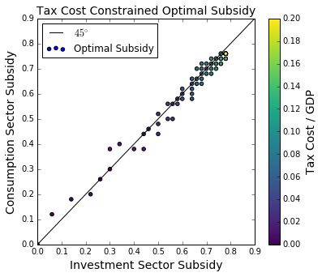

```python
plt.figure(figsize=(6,5))
plt.xlim(0,.9)
plt.ylim(0,.9)
t= cost_range
CS = plt.scatter(optimal_subsidy[1,:], optimal_subsidy[0,:], c=t, cmap='viridis',label='Optimal Subsidy')
cbar = plt.colorbar(CS)
cbar.ax.set_ylabel('Tax Cost / GDP',fontsize=14)
#plt.plot(optimal_subsidy[1,:],optimal_subsidy[0,:],'ro',label='Optimal Subsidy')
xlist = [x for x in np.linspace(0,.9,91)]
plt.plot(xlist,xlist,'k',label=r'$45^{\circ}$')
plt.xlabel('Investment Sector Subsidy',fontsize=14)
plt.ylabel('Consumption Sector Subsidy',fontsize=14)
plt.title('Tax Cost Constrained Optimal Subsidy',fontsize=14)
plt.legend(loc='upper left')
plt.savefig('constrained_optimal_subsidy_inc_only.pdf')
```

```python
cost = .43/.26*tax_cost_[10,10]
subsidies = [tax_cost_ <= cost]
opt_welfare = np.max(welfare[subsidies])
opt_subsidy = np.argwhere(welfare==opt_welfare)
optimal_subsidy=(ns[opt_subsidy[0,0]],ds[opt_subsidy[0,1]])
welfare[opt_subsidy[0,0],opt_subsidy[0,1]]
opt_welfare
```

```
1.0130001981993086
```

```python
import pandas as pd
```

```python
subsidy = pd.read_excel('RD-subsidies.xls',sheetname='Sheet1',index_col='Country')
subsidy = subsidy.sort_values('Gov_Support',ascending=False)
subsidy = subsidy / subsidy.ix["USA"]
drops = np.linspace(2,36,17)
drops = drops.astype(int)
subsidy = subsidy.drop(subsidy.index[drops])
```

```python
welfare_gain = np.zeros(len(subsidy.index))
for i in range(len(subsidy.index)):
    cost = subsidy.ix[i]['Gov_Support']*tax_cost_[10,10]
    subsidies = [tax_cost_ <= cost]
    opt_welfare = np.max(welfare[subsidies])
    opt_subsidy = np.argwhere(welfare==opt_welfare)
    optimal_subsidy=(ns[opt_subsidy[0,0]],ds[opt_subsidy[0,1]])
    welfare[opt_subsidy[0,0],opt_subsidy[0,1]]
    welfare_gain[i]=opt_welfare-1
```

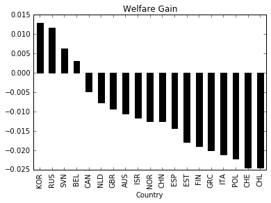

```python
subsidy['welfare_gain']=welfare_gain
subsidy = subsidy.drop(subsidy.index[4])
%matplotlib inline
subsidy['welfare_gain'].plot(kind='bar',color='k',legend=False)
plt.title('Welfare Gain')
plt.savefig('welfare_gain_country_comparison.pdf',bbox_inches='tight')
```

```python
subsidy.ix[5]['Gov_Support']
```

```
0.8076923076923076
```

**Calibration with single sector**

```python
B = innovation()
```

```python
b_n,b_d,z_d,z_n,g_c,g_r = .095,.095,.05,.05,.02,0
targets= [b_n,b_d,z_d,z_n,g_c,g_r]
B.calibration(targets,True)
```

```
(array([  2.61896926,   2.61896926,   1.09681858,   1.09681858,
          4.43666194,  14.7696668 ]), 2)
```

```python
B.equilibrium()
```

```
('CE = ',
 1,
 'TE = ',
 1,
 'optimal growth = ',
 0.01999999999999999,
 'decentral growth = ',
 0.01999999999999999,
 'tau_n = ',
 0.14499999999999985,
 'tau_d = ',
 0.14500000000000027,
 'z_n = ',
 0.049999999999999954,
 'b_n = ',
 0.094999999999999904,
 'z_d = ',
 0.0500000000000001,
 'b_d = ',
 0.095000000000000182,
 'Ln = ',
 0.70629183274393093,
 'Ld = ',
 0.21216308626375427,
 'Kn = ',
 4.1964841495045215,
 'Kd = ',
 1.2605823645968752,
 'K = ',
 5.4570665137563328)
```

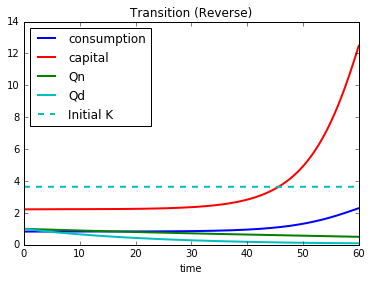

```
Welfare Gain 1.15546847661
```

```python
years, days, outyears  =60, 365, 5
n_e = (.2-B.gamma)/(1-B.gamma)
init_subs=(1-1/B.lambda_d,.2,.2,n_e,n_e)
n = .78
d = .78
n_e = (n-B.gamma)/(1-B.gamma)
d_e = (d-B.gamma)/(1-B.gamma)
subs = (1-1/B.lambda_d,n,d,n_e,n_e)
[long,short,medium,ss]=C.transition(init_subs,subs,years,days,outyears,graph=True)
cons_invs = B.Conseq
utility_invs = B.utility
print ('Welfare Gain', long)
```

**The Euler equation and entry distortionas are fixed at the calibration**

```python
C = innovation()
```

```python
b_n,b_d,z_d,z_n,g_c,g_r = .1,.09,.04,.06,.02,-.02
targets= [b_n,b_d,z_d,z_n,g_c,g_r]
C.calibration(targets,True)
```

```
(array([  2.15165741,   3.375     ,   1.04341606,   1.22894226,
         13.65691567,   5.4819443 ]), 2)
```

```python
C.equilibrium()
```

```
('CE = ',
 1,
 'TE = ',
 1,
 'optimal growth = ',
 0.019999999999999851,
 'decentral growth = ',
 0.019999999999999851,
 'tau_n = ',
 0.16000000000006567,
 'tau_d = ',
 0.12999999999997114,
 'z_n = ',
 0.060000000000024638,
 'b_n = ',
 0.10000000000004103,
 'z_d = ',
 0.039999999999991126,
 'b_d = ',
 0.089999999999980013,
 'Ln = ',
 0.69555647244958174,
 'Ld = ',
 0.22877106553988127,
 'Kn = ',
 3.1481312810115352,
 'Kd = ',
 1.0354318824466766,
 'K = ',
 4.1835631632768919)
```

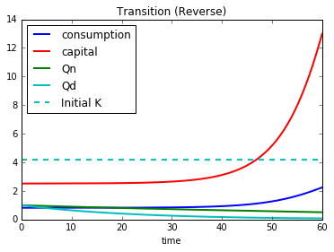

```
Welfare Gain 1.14863728236
```

```python
years, days, outyears  =60, 365, 5
n_e = (.2-C.gamma)/(1-C.gamma)
init_subs=(1-1/C.lambda_d,.2,.2,n_e,n_e)
n = .78
d = .78
n_e = (n-C.gamma)/(1-C.gamma)
d_e = (d-C.gamma)/(1-C.gamma)
subs = (1-1/C.lambda_d,n,d,n_e,n_e)
[long,short,medium,ss]=C.transition(init_subs,subs,years,days,outyears,graph=True)
cons_invs = C.Conseq
utility_invs = C.utility
print ('Welfare Gain', long)
```

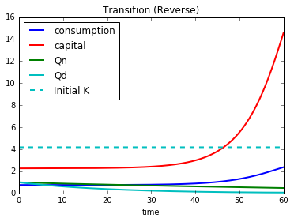

```
Welfare Gain 1.15329392009
```

```python
years, days, outyears  =60, 365, 5
n_e = (.2-C.gamma)/(1-C.gamma)
init_subs=(1-1/C.lambda_d,.2,.2,n_e,n_e)
n = .82
d = .82
n_e = ( n-C.gamma)/(1-C.gamma)
d_e = ( d-C.gamma)/(1-C.gamma)

subs = (1-1/C.lambda_d,n,d,n_e,d_e)
[long,short,medium,ss]=C.transition(init_subs,subs,years,days,outyears,graph=True)
cons_invs = C.Conseq
utility_invs = C.utility
print ('Welfare Gain', long)
```

```python
years, days, outyears  = 72, 365, 5
nsub = 46
n_e = (.2-C.gamma)/(1-C.gamma)
init_subs=(1-1/C.lambda_d,.2,.2,n_e,n_e)
upper_bound = .9
ns = np.linspace(0,upper_bound,nsub)
ds = np.linspace(0,upper_bound,nsub)
welfareC    = np.zeros((nsub,nsub))
welfareC_10 = np.zeros((nsub,nsub))
welfareC_20 = np.zeros((nsub,nsub))
welfareC_ss = np.zeros((nsub,nsub))
for index,n in enumerate(ns):
    print ('Outer loop =', index)
    n_ent = (n-C.gamma)/(1-C.gamma)
    for index2,d in enumerate(ds):
        #print ('Inner loop =', index2)
        d_ent = (d-C.gamma)/(1-C.gamma)
        subs = (1-1/C.lambda_d,n,d,n_ent,d_ent)
        welfareC[index,index2],welfareC_10[index,index2],welfareC_20[index,index2],welfareC_ss[index,index2] = C.transition(init_subs,subs,years,days,outyears)
```

```
Outer loop = 0
Outer loop = 1
Outer loop = 2
Outer loop = 3
Outer loop = 4
Outer loop = 5
Outer loop = 6
Outer loop = 7
Outer loop = 8
Outer loop = 9
Outer loop = 10
Outer loop = 11
Outer loop = 12
Outer loop = 13
Outer loop = 14
Outer loop = 15
Outer loop = 16
Outer loop = 17
Outer loop = 18
Outer loop = 19
Outer loop = 20
Outer loop = 21
Outer loop = 22
Outer loop = 23
Outer loop = 24
Outer loop = 25
Outer loop = 26
Outer loop = 27
Outer loop = 28
Outer loop = 29
Outer loop = 30
Outer loop = 31
Outer loop = 32
Outer loop = 33
Outer loop = 34
Outer loop = 35
Outer loop = 36
Outer loop = 37
Outer loop = 38
Outer loop = 39
Outer loop = 40
Outer loop = 41
Outer loop = 42
Outer loop = 43
Outer loop = 44
Outer loop = 45
```

```python
np.savetxt("welfare_convex_fix_dist_cal.csv", welfareC, delimiter=",")
```

```python
opt_wel=np.max(welfareC)
a = np.argwhere(welfareC==opt_wel)
print ('Con Subsidy', ns[a[0,0]],'Inv Subsidy', ds[a[0,1]],'Welfare',opt_wel)
```

```
Con Subsidy 0.86 Inv Subsidy 0.8 Welfare 1.15868295937
```

```python
nsub = 46
upper_bound = .9
ns = np.linspace(0,upper_bound,nsub)
ds = np.linspace(0,upper_bound,nsub)
tax_cost_ = C.costs(nsub,upper_bound,both=True,differ=True,inv_sub=True)
```

```python
np.savetxt("cost_convex_fix_dist_cal.csv", tax_cost_, delimiter=",")
```

```python
%matplotlib inline
CS = plt.contourf(ds, ns, welfareC, 15,
                  cmap=plt.cm.bone,
                  origin='upper')

plt.title('Welfare Gain',fontsize=14)
plt.xlabel('Investment Sector Subsidy',fontsize=14)
plt.ylabel('Consumption Sector Subsidy',fontsize=14)

plt.plot(ds[a[0,1]],ns[a[0,0]],marker='o', color='r', ls='')
txt = '{0:.3f}'.format(welfareC[a[0,0],a[0,1]])
plt.annotate(txt,(ds[a[0,1]],ns[a[0,0]]),horizontalalignment='right',
             verticalalignment='top')

# Make a colorbar for the ContourSet returned by the contourf call.
cbar = plt.colorbar(CS)
cbar.ax.set_ylabel('Welfare Gain',fontsize=14)


CS2 = plt.contour(ds, ns, tax_cost_,[0,.01,.02,.03,.04,.08,.12,.16,.2])
plt.clabel(CS2, inline=1, fontsize=10)

plt.savefig("welfare-trans-convex_fix_dist_cal.pdf",bbox_inches='tight')
plt.close()
```

```python
cost_points = 91
optimal_subsidy = np.zeros((2,cost_points))
cost_range = np.linspace(tax_cost_[10,10],.2,cost_points)
for i in range(cost_points):
    #cost = tax_cost_[i,i]
    cost = cost_range[i]
    subsidies = [tax_cost_ <= cost]
    opt_welfare = np.max(welfareC[subsidies])
    opt_subsidy = np.argwhere(welfareC==opt_welfare)
    optimal_subsidy[:,i]=(ns[opt_subsidy[0,0]],ds[opt_subsidy[0,1]])
    print ('Cost', '{0:.3f}'.format(cost),
           'Inv Subsidy' , '{0:.2f}'.format(ds[opt_subsidy[0,1]]),'Con Subsidy' ,'{0:.2f}'.format(ns[opt_subsidy[0,0]]),
           'Optimal Welfare', '{0:.4f}'.format(opt_welfare))
```

```
Cost 0.009 Inv Subsidy 0.20 Con Subsidy 0.20 Optimal Welfare 1.0000
Cost 0.011 Inv Subsidy 0.12 Con Subsidy 0.34 Optimal Welfare 1.0055
Cost 0.013 Inv Subsidy 0.14 Con Subsidy 0.38 Optimal Welfare 1.0114
Cost 0.015 Inv Subsidy 0.18 Con Subsidy 0.40 Optimal Welfare 1.0172
Cost 0.018 Inv Subsidy 0.24 Con Subsidy 0.40 Optimal Welfare 1.0230
Cost 0.020 Inv Subsidy 0.24 Con Subsidy 0.44 Optimal Welfare 1.0276
Cost 0.022 Inv Subsidy 0.30 Con Subsidy 0.44 Optimal Welfare 1.0338
Cost 0.024 Inv Subsidy 0.32 Con Subsidy 0.46 Optimal Welfare 1.0385
Cost 0.026 Inv Subsidy 0.34 Con Subsidy 0.48 Optimal Welfare 1.0432
Cost 0.028 Inv Subsidy 0.38 Con Subsidy 0.48 Optimal Welfare 1.0479
Cost 0.030 Inv Subsidy 0.36 Con Subsidy 0.52 Optimal Welfare 1.0509
Cost 0.032 Inv Subsidy 0.40 Con Subsidy 0.52 Optimal Welfare 1.0556
Cost 0.034 Inv Subsidy 0.38 Con Subsidy 0.56 Optimal Welfare 1.0590
Cost 0.037 Inv Subsidy 0.44 Con Subsidy 0.54 Optimal Welfare 1.0635
Cost 0.039 Inv Subsidy 0.42 Con Subsidy 0.58 Optimal Welfare 1.0669
Cost 0.041 Inv Subsidy 0.42 Con Subsidy 0.60 Optimal Welfare 1.0700
Cost 0.043 Inv Subsidy 0.50 Con Subsidy 0.56 Optimal Welfare 1.0744
Cost 0.045 Inv Subsidy 0.50 Con Subsidy 0.58 Optimal Welfare 1.0775
Cost 0.047 Inv Subsidy 0.50 Con Subsidy 0.60 Optimal Welfare 1.0806
Cost 0.049 Inv Subsidy 0.50 Con Subsidy 0.62 Optimal Welfare 1.0839
Cost 0.051 Inv Subsidy 0.52 Con Subsidy 0.62 Optimal Welfare 1.0867
Cost 0.054 Inv Subsidy 0.54 Con Subsidy 0.62 Optimal Welfare 1.0895
Cost 0.056 Inv Subsidy 0.56 Con Subsidy 0.62 Optimal Welfare 1.0924
Cost 0.058 Inv Subsidy 0.52 Con Subsidy 0.66 Optimal Welfare 1.0935
Cost 0.060 Inv Subsidy 0.52 Con Subsidy 0.68 Optimal Welfare 1.0971
Cost 0.062 Inv Subsidy 0.54 Con Subsidy 0.68 Optimal Welfare 1.1000
Cost 0.064 Inv Subsidy 0.58 Con Subsidy 0.66 Optimal Welfare 1.1022
Cost 0.066 Inv Subsidy 0.54 Con Subsidy 0.70 Optimal Welfare 1.1036
Cost 0.068 Inv Subsidy 0.56 Con Subsidy 0.70 Optimal Welfare 1.1065
Cost 0.071 Inv Subsidy 0.58 Con Subsidy 0.70 Optimal Welfare 1.1095
Cost 0.073 Inv Subsidy 0.56 Con Subsidy 0.72 Optimal Welfare 1.1103
Cost 0.075 Inv Subsidy 0.58 Con Subsidy 0.72 Optimal Welfare 1.1132
Cost 0.077 Inv Subsidy 0.62 Con Subsidy 0.70 Optimal Welfare 1.1154
Cost 0.079 Inv Subsidy 0.60 Con Subsidy 0.72 Optimal Welfare 1.1162
Cost 0.081 Inv Subsidy 0.62 Con Subsidy 0.72 Optimal Welfare 1.1192
Cost 0.083 Inv Subsidy 0.60 Con Subsidy 0.74 Optimal Welfare 1.1200
Cost 0.085 Inv Subsidy 0.64 Con Subsidy 0.72 Optimal Welfare 1.1221
Cost 0.088 Inv Subsidy 0.62 Con Subsidy 0.74 Optimal Welfare 1.1230
Cost 0.090 Inv Subsidy 0.64 Con Subsidy 0.74 Optimal Welfare 1.1259
Cost 0.092 Inv Subsidy 0.62 Con Subsidy 0.76 Optimal Welfare 1.1267
```

[output cut: 36 more lines]

```
Cost 0.170 Inv Subsidy 0.76 Con Subsidy 0.84 Optimal Welfare 1.1568
Cost 0.172 Inv Subsidy 0.76 Con Subsidy 0.84 Optimal Welfare 1.1568
Cost 0.175 Inv Subsidy 0.76 Con Subsidy 0.84 Optimal Welfare 1.1568
Cost 0.177 Inv Subsidy 0.76 Con Subsidy 0.84 Optimal Welfare 1.1568
Cost 0.179 Inv Subsidy 0.78 Con Subsidy 0.84 Optimal Welfare 1.1578
Cost 0.181 Inv Subsidy 0.78 Con Subsidy 0.84 Optimal Welfare 1.1578
Cost 0.183 Inv Subsidy 0.78 Con Subsidy 0.84 Optimal Welfare 1.1578
Cost 0.185 Inv Subsidy 0.78 Con Subsidy 0.84 Optimal Welfare 1.1578
Cost 0.187 Inv Subsidy 0.78 Con Subsidy 0.84 Optimal Welfare 1.1578
Cost 0.189 Inv Subsidy 0.78 Con Subsidy 0.84 Optimal Welfare 1.1578
Cost 0.192 Inv Subsidy 0.78 Con Subsidy 0.84 Optimal Welfare 1.1578
Cost 0.194 Inv Subsidy 0.78 Con Subsidy 0.86 Optimal Welfare 1.1586
Cost 0.196 Inv Subsidy 0.78 Con Subsidy 0.86 Optimal Welfare 1.1586
Cost 0.198 Inv Subsidy 0.78 Con Subsidy 0.86 Optimal Welfare 1.1586
Cost 0.200 Inv Subsidy 0.78 Con Subsidy 0.86 Optimal Welfare 1.1586
```

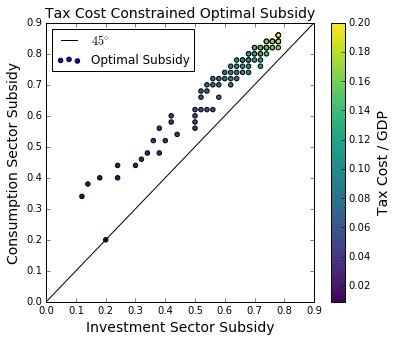

```python
plt.figure(figsize=(6,5))
plt.xlim(0,.9)
plt.ylim(0,.9)
t= cost_range
CS = plt.scatter(optimal_subsidy[1,:], optimal_subsidy[0,:], c=t, cmap='viridis',label='Optimal Subsidy')
cbar = plt.colorbar(CS)
cbar.ax.set_ylabel('Tax Cost / GDP',fontsize=14)
#plt.plot(optimal_subsidy[1,:],optimal_subsidy[0,:],'ro',label='Optimal Subsidy')
xlist = [x for x in np.linspace(0,.9,91)]
plt.plot(xlist,xlist,'k',label=r'$45^{\circ}$')
plt.xlabel('Investment Sector Subsidy',fontsize=14)
plt.ylabel('Consumption Sector Subsidy',fontsize=14)
plt.title('Tax Cost Constrained Optimal Subsidy',fontsize=14)
plt.legend(loc='upper left')
```

```python
mar_cost_inc_n = 1/(1-A.gamma)*A.chi_in*A.b_n**(A.gamma/(1-A.gamma))
mar_cost_inc_d = 1/(1-A.gamma)*A.chi_id*A.b_d**(A.gamma/(1-A.gamma))
profit_n = A.Ln*(A.lambda_n-1)/(1-A.theta)*A.w-A.w*A.chi_in*A.b_n**(1/(1-A.gamma))
profit_d = A.Ld*(A.lambda_d-1)/(1-A.alpha)*A.w-A.w*A.chi_id*A.b_d**(1/(1-A.gamma))
discount_n = A.rho+A.tau_n-A.b_n
discount_d = A.rho+A.tau_d-A.b_d
print ('Marginal cost n ',mar_cost_inc_n)
print ('Marginal cost d ',mar_cost_inc_d)
print ('Net profit n', profit_n)
print ('Net profit d', profit_d)
print ('Wage Rate', A.w)
print ('Adjusted Discount Factor n', discount_n)
print ('Adjusted Discount Factor d', discount_d)
```

```
Marginal cost n  0.300435208611
Marginal cost d  0.912574957756
Net profit n 0.0199889722839
Net profit d 0.0462964866447
Wage Rate 1.03958418815
Adjusted Discount Factor n 0.09
Adjusted Discount Factor d 0.07
```

```python
inc_inn_sp_n = 0.18253608975642593
inc_inn_sp_d = 0.16905376527078167
inn_sp_n     = 0.25153040831131224
inn_sp_d     = 0.21638585358825826
K_n          = 2.1016822527144847
L_n          = 0.4930515604109168
mar_cost_inc_sp_n = 1/(1-A.gamma)*A.chi_in*inc_inn_sp_n**(A.gamma/(1-A.gamma))
mar_cost_inc_sp_d = 1/(1-A.gamma)*A.chi_id*inc_inn_sp_d**(A.gamma/(1-A.gamma))
mar_pro_n         = (1-A.theta)*K_n**A.theta*L_n**(-A.theta)
cons              = K_n**A.theta*L_n**(1-A.theta)
print ('Marginal Cost n', mar_cost_inc_sp_n)
print ('Marginal Cost d', mar_cost_inc_sp_d)
print ('Marginal Product of Labor ',mar_pro_n)
print ('Log innovative step n ', np.log(A.lambda_n))
print ('Log innovative step d ', np.log(A.lambda_d))
print ('Consumption ', cons)
print ('Discount Factor ', A.rho)
```

```
Marginal Cost n 0.74092447583
Marginal Cost d 2.34931934583
Marginal Product of Labor  1.073749502328753
Log innovative step n  0.0275
Log innovative step d  0.193846153846
Consumption  0.8678915862518641
Discount Factor  0.03
```

```python
optimum_inn = np.array([.252,.216])
A.optimum_subsidy(optimum_inn)
```

```
(array([ 0.8237853,  0.7705431]), 2)
```

```
growth rate 0.0331579366991
```

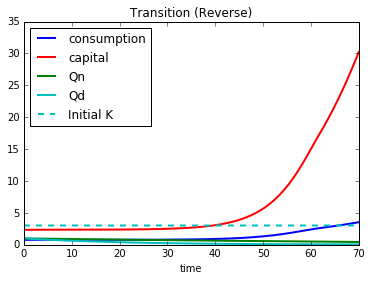

```
array([ 1.14665229,  0.8336411 ,  0.85785677])
```

```python
years, days, outyears  =70, 365, 5
nsub = 36
init_subs=(0,.2,.2,0,0)
n = .82
d = .78
n_e = (n-A.gamma)/(1-A.gamma)
d_e = (d-A.gamma)/(1-A.gamma)
subs = (1-1/A.lambda_d,n,d,n_e,d_e)
A.transition(init_subs,subs,years,days,outyears,graph=True)
```

```python
years, days, outyears  = 52, 365, 5
nsub = 46
init_subs=(0,.2,.2,0,0)
upper_bound = .9
ns = np.linspace(0,upper_bound,nsub)
ds = np.linspace(0,upper_bound,nsub)
welfare = np.zeros((nsub,nsub))
for index,n in enumerate(ns):
    print ('Outer loop =', index)
    for index2,d in enumerate(ds):
        print ('Inner loop =', index2)
        subs = (0,n,d,0,0)
        welfare[index,index2]=A.transition(init_subs,subs,years,days,outyears)[0]
```

[output not shown]

[output cut: 2107 more lines]

```
Inner loop = 31
Inner loop = 32
Inner loop = 33
Inner loop = 34
Inner loop = 35
Inner loop = 36
Inner loop = 37
Inner loop = 38
Inner loop = 39
Inner loop = 40
Inner loop = 41
Inner loop = 42
Inner loop = 43
Inner loop = 44
Inner loop = 45
```

```python
np.savetxt("welfare_convex_inc_ncg-46.csv", welfare, delimiter=",")
```

```python
welfare = np.loadtxt("welfare_convex_inc_ncg-46.csv",delimiter=",")
```

```python
nsub = 46
upper_bound = .9
ns = np.linspace(0,upper_bound,nsub)
ds = np.linspace(0,upper_bound,nsub)
tax_cost = A.costs(nsub,upper_bound,both=False)
```

```python
tax_cost[15,0]
```

```
0.0027535437355969889
```

```python
%matplotlib inline
plt.plot(ns,tax_cost[6,:],'r',linewidth=2,label=r'R&D cost wrt $s^i_d$')
plt.plot(ns,tax_cost[:,6],'b',linewidth=2,label=r'R&D cost wrt $s^i_n$')
plt.plot(ns,tax_cost.diagonal(),'black',linewidth=2,label=r'R&D cost wrt $s^i_n$,$s^i_d$')
plt.xlabel('R&D subsidy')
plt.ylabel('Subsidy Cost')
plt.legend(loc='best')
plt.title('Subsidy Cost as a Share of Output')
plt.show()
```

[output not shown]

```python
taun_all, taud_all = A.innovative_response(nsub,upper_bound,both=False)
```

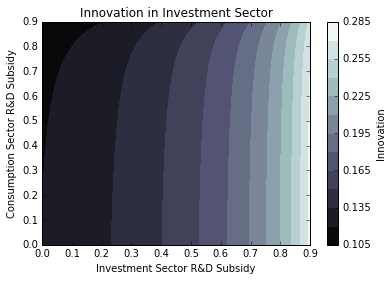

```python
CS_n = plt.contourf(ds, ns, taun_all, 15,
            cmap=plt.cm.bone, origin='upper')

plt.title('Innovation in Consumption Sector')
plt.xlabel('Investment Sector R&D Subsidy')
plt.ylabel('Consumption Sector R&D Subsidy')

cbar_n = plt.colorbar(CS_n)
cbar_n.ax.set_ylabel('Innovation')

plt.savefig('con_inn_sub_inc_partial.pdf')

plt.close()

CS_d = plt.contourf(ds, ns, taud_all, 15,
            cmap=plt.cm.bone,origin='upper')

plt.title('Innovation in Investment Sector')
plt.xlabel('Investment Sector R&D Subsidy')
plt.ylabel('Consumption Sector R&D Subsidy')

cbar_d = plt.colorbar(CS_d)
cbar_d.ax.set_ylabel('Innovation')

plt.savefig('inv_inn_sub_inc_partial.pdf')
```

```python
for i in range(nsub):
    for j in range(nsub):
        if not (A.correct[i,j]):
            welfare[i,j]=.9
```

```python
opt_wel=np.max(welfare)
a = np.argwhere(welfare==opt_wel)
print ('Con Subsidy', ns[a[0,0]],'Inv Subsidy', ds[a[0,1]],'Welfare',opt_wel)
```

```
Con Subsidy 0.76 Inv Subsidy 0.78 Welfare 1.11022824995
```

```python
for i in range(nsub):
    cost = tax_cost[i,i]
    subsidies = [tax_cost <= cost]
    opt_welfare = np.max(welfare[subsidies])
    opt_subsidy = np.argwhere(welfare==opt_welfare)
    print ('Uniform Subsidy','{0:.2f}'.format(ns[i]) ,
           'Welfare','{0:.4f}'.format(welfare[i,i]), 'Cost', '{0:.3f}'.format(cost),
           'Inv Subsidy' , '{0:.2f}'.format(ds[opt_subsidy[0,1]]),'Con Subsidy' ,'{0:.2f}'.format(ns[opt_subsidy[0,0]]),
           'Optimal Welfare', '{0:.4f}'.format(opt_welfare))
```

```
Uniform Subsidy 0.00 Welfare 0.9739 Cost 0.000 Inv Subsidy 0.00 Con Subsidy 0.00 Optimal Welfare 0.9739
Uniform Subsidy 0.02 Welfare 0.9762 Cost 0.000 Inv Subsidy 0.02 Con Subsidy 0.02 Optimal Welfare 0.9762
Uniform Subsidy 0.04 Welfare 0.9786 Cost 0.001 Inv Subsidy 0.04 Con Subsidy 0.04 Optimal Welfare 0.9786
Uniform Subsidy 0.06 Welfare 0.9810 Cost 0.001 Inv Subsidy 0.06 Con Subsidy 0.06 Optimal Welfare 0.9810
Uniform Subsidy 0.08 Welfare 0.9835 Cost 0.002 Inv Subsidy 0.08 Con Subsidy 0.08 Optimal Welfare 0.9835
Uniform Subsidy 0.10 Welfare 0.9861 Cost 0.002 Inv Subsidy 0.10 Con Subsidy 0.10 Optimal Welfare 0.9861
Uniform Subsidy 0.12 Welfare 0.9887 Cost 0.003 Inv Subsidy 0.12 Con Subsidy 0.12 Optimal Welfare 0.9887
Uniform Subsidy 0.14 Welfare 0.9914 Cost 0.004 Inv Subsidy 0.14 Con Subsidy 0.14 Optimal Welfare 0.9914
Uniform Subsidy 0.16 Welfare 0.9942 Cost 0.004 Inv Subsidy 0.16 Con Subsidy 0.16 Optimal Welfare 0.9942
Uniform Subsidy 0.18 Welfare 0.9970 Cost 0.005 Inv Subsidy 0.18 Con Subsidy 0.18 Optimal Welfare 0.9970
Uniform Subsidy 0.20 Welfare 1.0000 Cost 0.006 Inv Subsidy 0.20 Con Subsidy 0.20 Optimal Welfare 1.0000
Uniform Subsidy 0.22 Welfare 1.0030 Cost 0.006 Inv Subsidy 0.22 Con Subsidy 0.22 Optimal Welfare 1.0030
Uniform Subsidy 0.24 Welfare 1.0061 Cost 0.007 Inv Subsidy 0.24 Con Subsidy 0.24 Optimal Welfare 1.0061
Uniform Subsidy 0.26 Welfare 1.0093 Cost 0.008 Inv Subsidy 0.26 Con Subsidy 0.26 Optimal Welfare 1.0093
Uniform Subsidy 0.28 Welfare 1.0126 Cost 0.009 Inv Subsidy 0.28 Con Subsidy 0.28 Optimal Welfare 1.0126
Uniform Subsidy 0.30 Welfare 1.0160 Cost 0.010 Inv Subsidy 0.30 Con Subsidy 0.30 Optimal Welfare 1.0160
Uniform Subsidy 0.32 Welfare 1.0194 Cost 0.011 Inv Subsidy 0.32 Con Subsidy 0.32 Optimal Welfare 1.0194
Uniform Subsidy 0.34 Welfare 1.0230 Cost 0.013 Inv Subsidy 0.34 Con Subsidy 0.34 Optimal Welfare 1.0230
Uniform Subsidy 0.36 Welfare 1.0267 Cost 0.014 Inv Subsidy 0.36 Con Subsidy 0.36 Optimal Welfare 1.0267
Uniform Subsidy 0.38 Welfare 1.0305 Cost 0.015 Inv Subsidy 0.38 Con Subsidy 0.38 Optimal Welfare 1.0305
Uniform Subsidy 0.40 Welfare 1.0344 Cost 0.017 Inv Subsidy 0.40 Con Subsidy 0.40 Optimal Welfare 1.0344
Uniform Subsidy 0.42 Welfare 1.0384 Cost 0.019 Inv Subsidy 0.42 Con Subsidy 0.42 Optimal Welfare 1.0384
Uniform Subsidy 0.44 Welfare 1.0425 Cost 0.021 Inv Subsidy 0.44 Con Subsidy 0.44 Optimal Welfare 1.0425
Uniform Subsidy 0.46 Welfare 1.0467 Cost 0.023 Inv Subsidy 0.46 Con Subsidy 0.46 Optimal Welfare 1.0467
Uniform Subsidy 0.48 Welfare 1.0510 Cost 0.025 Inv Subsidy 0.48 Con Subsidy 0.48 Optimal Welfare 1.0510
Uniform Subsidy 0.50 Welfare 1.0554 Cost 0.027 Inv Subsidy 0.50 Con Subsidy 0.50 Optimal Welfare 1.0554
Uniform Subsidy 0.52 Welfare 1.0600 Cost 0.030 Inv Subsidy 0.52 Con Subsidy 0.52 Optimal Welfare 1.0600
Uniform Subsidy 0.54 Welfare 1.0646 Cost 0.033 Inv Subsidy 0.54 Con Subsidy 0.54 Optimal Welfare 1.0646
Uniform Subsidy 0.56 Welfare 1.0693 Cost 0.037 Inv Subsidy 0.56 Con Subsidy 0.56 Optimal Welfare 1.0693
Uniform Subsidy 0.58 Welfare 1.0740 Cost 0.040 Inv Subsidy 0.58 Con Subsidy 0.58 Optimal Welfare 1.0740
Uniform Subsidy 0.60 Welfare 1.0788 Cost 0.045 Inv Subsidy 0.60 Con Subsidy 0.60 Optimal Welfare 1.0788
Uniform Subsidy 0.62 Welfare 1.0836 Cost 0.049 Inv Subsidy 0.62 Con Subsidy 0.62 Optimal Welfare 1.0836
Uniform Subsidy 0.64 Welfare 1.0883 Cost 0.055 Inv Subsidy 0.64 Con Subsidy 0.64 Optimal Welfare 1.0883
Uniform Subsidy 0.66 Welfare 1.0929 Cost 0.061 Inv Subsidy 0.66 Con Subsidy 0.66 Optimal Welfare 1.0929
Uniform Subsidy 0.68 Welfare 1.0973 Cost 0.068 Inv Subsidy 0.68 Con Subsidy 0.68 Optimal Welfare 1.0973
Uniform Subsidy 0.70 Welfare 1.1014 Cost 0.076 Inv Subsidy 0.70 Con Subsidy 0.70 Optimal Welfare 1.1014
Uniform Subsidy 0.72 Welfare 1.1050 Cost 0.086 Inv Subsidy 0.72 Con Subsidy 0.72 Optimal Welfare 1.1050
Uniform Subsidy 0.74 Welfare 1.1079 Cost 0.097 Inv Subsidy 0.74 Con Subsidy 0.74 Optimal Welfare 1.1079
Uniform Subsidy 0.76 Welfare 1.1097 Cost 0.111 Inv Subsidy 0.76 Con Subsidy 0.76 Optimal Welfare 1.1097
Uniform Subsidy 0.78 Welfare 1.1101 Cost 0.128 Inv Subsidy 0.78 Con Subsidy 0.76 Optimal Welfare 1.1102
Uniform Subsidy 0.80 Welfare 1.1083 Cost 0.148 Inv Subsidy 0.78 Con Subsidy 0.76 Optimal Welfare 1.1102
Uniform Subsidy 0.82 Welfare 1.1035 Cost 0.173 Inv Subsidy 0.78 Con Subsidy 0.76 Optimal Welfare 1.1102
Uniform Subsidy 0.84 Welfare 1.0945 Cost 0.205 Inv Subsidy 0.78 Con Subsidy 0.76 Optimal Welfare 1.1102
Uniform Subsidy 0.86 Welfare 1.0792 Cost 0.248 Inv Subsidy 0.78 Con Subsidy 0.76 Optimal Welfare 1.1102
Uniform Subsidy 0.88 Welfare 1.0547 Cost 0.306 Inv Subsidy 0.78 Con Subsidy 0.76 Optimal Welfare 1.1102
Uniform Subsidy 0.90 Welfare 1.0164 Cost 0.390 Inv Subsidy 0.78 Con Subsidy 0.76 Optimal Welfare 1.1102
```

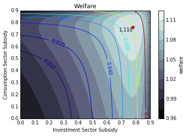

```python
%matplotlib inline
CS = plt.contourf(ds, ns, welfare, 12,
                  cmap=plt.cm.bone,
                  origin='upper')

plt.title('Welfare')
plt.xlabel('Investment Sector Subsidy')
plt.ylabel('Consumption Sector Subsidy')

plt.plot(ds[a[0,1]],ns[a[0,0]],marker='o', color='r', ls='')
txt = '{0:.3f}'.format(welfare[a[0,0],a[0,1]])
plt.annotate(txt,(ds[a[0,1]],ns[a[0,0]]),horizontalalignment='right',
             verticalalignment='top')



# Make a colorbar for the ContourSet returned by the contourf call.
cbar = plt.colorbar(CS)
cbar.ax.set_ylabel('welfare')


CS2 = plt.contour(ds, ns, tax_cost,[.01,.02,.04,.06,.08,.12,.2])
plt.clabel(CS2, inline=1, fontsize=10)
#plt.title('tax_cost')

plt.savefig("welfare-trans-convex_inc.pdf",bbox_inches='tight')
```

Now I conduct experiments where both entrants and incumbents are subsidized

```python
subs = (0,.8,.8,.8,.8)
A.transition(init_subs,subs,years,days,outyears)
```

```
1.0587605720078674
```

```python
years, days, outyears  = 70, 365, 5
nsub = 46
upper_bound = .9
init_subs=(0,.2,.2,0,0)
ns = np.linspace(0,upper_bound,nsub)
ds = np.linspace(0,upper_bound,nsub)
welfare2 = np.zeros((nsub,nsub))
for index,n in enumerate(ns):
    print ('Outer loop =', index)
    for index2,d in enumerate(ds):
        print ('Inner loop =', index2)
        subs = (0,n,d,n,d)
        welfare2[index,index2]=A.transition(init_subs,subs,years,days,outyears)[0]
```

[output not shown]

[output not shown]

[output cut: 2065 more lines]

```
Inner loop = 31
Inner loop = 32
Inner loop = 33
Inner loop = 34
Inner loop = 35
Inner loop = 36
Inner loop = 37
Inner loop = 38
Inner loop = 39
Inner loop = 40
Inner loop = 41
Inner loop = 42
Inner loop = 43
Inner loop = 44
Inner loop = 45
```

```python
np.savetxt("welfare_convex_entry_inc_46.csv", welfare2, delimiter=",")
```

```python
welfare2 = np.loadtxt("welfare_convex_entry_inc_46.csv",delimiter=",")
```

```python
nsub = 46
upper_bound = .9
ns = np.linspace(0,upper_bound,nsub)
ds = np.linspace(0,upper_bound,nsub)
tax_cost = A.costs(nsub,upper_bound,both=True)
```

```python
%matplotlib inline
plt.plot(ns,tax_cost[6,:],'r',linewidth=2,label=r'R&D cost wrt $s^i_d$')
plt.plot(ns,tax_cost[:,6],'b',linewidth=2,label=r'R&D cost wrt $s^i_n$')
plt.plot(ns,tax_cost.diagonal(),'black',linewidth=2,label=r'R&D cost wrt $s^i_n$,$s^i_d$')
plt.xlabel('R&D subsidy')
plt.ylabel('Subsidy Cost')
plt.legend(loc='best')
plt.title('Subsidy Cost as a Share of Output')
plt.show()
```

[output not shown]

```python
taun_all, taud_all = A.innovative_response(nsub,upper_bound,both=True)
```

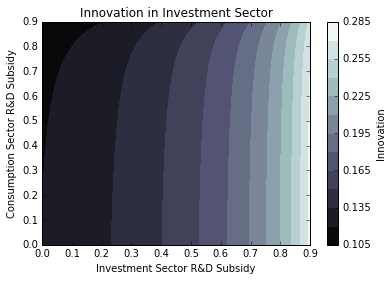

```python
CS_n = plt.contourf(ds, ns, taun_all, 15,
            cmap=plt.cm.bone, origin='upper')

plt.title('Innovation in Consumption Sector')
plt.xlabel('Investment Sector R&D Subsidy')
plt.ylabel('Consumption Sector R&D Subsidy')

cbar_n = plt.colorbar(CS_n)
cbar_n.ax.set_ylabel('Innovation')

plt.savefig('con_inn_sub_ent_inc_partial.pdf')

plt.close()

CS_d = plt.contourf(ds, ns, taud_all, 15,
            cmap=plt.cm.bone,origin='upper')

plt.title('Innovation in Investment Sector')
plt.xlabel('Investment Sector R&D Subsidy')
plt.ylabel('Consumption Sector R&D Subsidy')

cbar_d = plt.colorbar(CS_d)
cbar_d.ax.set_ylabel('Innovation')

plt.savefig('inv_inn_sub_ent_inc_partial.pdf')
```

```python
nsub = 46
upper_bound = .9
ns = np.linspace(0,upper_bound,nsub)
ds = np.linspace(0,upper_bound,nsub)
taun_all, taud_all = A.innovative_response(nsub,upper_bound,both=True,inv_sub=True)
```

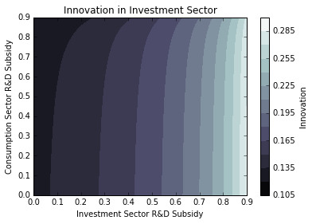

```python
CS_n = plt.contourf(ds, ns, taun_all, 15,
            cmap=plt.cm.bone, origin='upper')

plt.title('Innovation in Consumption Sector')
plt.xlabel('Investment Sector R&D Subsidy')
plt.ylabel('Consumption Sector R&D Subsidy')

cbar_n = plt.colorbar(CS_n)
cbar_n.ax.set_ylabel('Innovation')

plt.savefig('con_inn_sub_ent_inc_inv.pdf')

plt.close()

CS_d = plt.contourf(ds, ns, taud_all, 15,
            cmap=plt.cm.bone,origin='upper')

plt.title('Innovation in Investment Sector')
plt.xlabel('Investment Sector R&D Subsidy')
plt.ylabel('Consumption Sector R&D Subsidy')

cbar_d = plt.colorbar(CS_d)
cbar_d.ax.set_ylabel('Innovation')

plt.savefig('inv_inn_sub_ent_inc_inv.pdf')
```

```python
g_C = np.zeros((nsub,nsub))
for n in range(nsub):
    for d in range(nsub):
        g_C[n,d]=taun_all[n,d]*np.log(A.lambda_n)+(A.theta)/(1-A.alpha)*taud_all[n,d]*np.log(A.lambda_d)
```

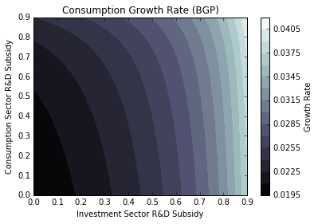

```python
CS = plt.contourf(ds, ns, g_C, 15,
            cmap=plt.cm.bone,origin='upper')

plt.title('Consumption Growth Rate (BGP)')
plt.xlabel('Investment Sector R&D Subsidy')
plt.ylabel('Consumption Sector R&D Subsidy')

cbar_d = plt.colorbar(CS)
cbar_d.ax.set_ylabel('Growth Rate')

plt.savefig('cons_growth_ent_inc_inv.pdf')
```

[output not shown]

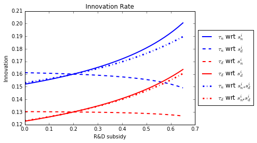

```python
# How do innovation rates react to subsidies?
A.innovative_response()
```

```python
# This exercise was conducted with initial way of calculating CE
# However, the numbers are still valid
# Calculate the innovation rates with uniform subsidy (.3)
# and non-uniform subsidy (.05,.35)

z_n_u,b_n_u = float(uniform[9]),float(uniform[13])#0.05646,0.10931
z_n_n,b_n_n = float(non_uniform[9]),float(non_uniform[13])#0.06507,0.08918

z_d_u,b_d_u = float(uniform[11]),float(uniform[15])#0.03517,0.09838
z_d_n,b_d_n = float(non_uniform[11]),float(non_uniform[15])#0.03293,0.10336

l_rd_n_u = A.chi_en*A.psi_n*z_n_u+A.chi_in*b_n_u**(1/(1-A.gamma))
l_rd_n_n = A.chi_en*A.psi_n*z_n_n+A.chi_in*b_n_n**(1/(1-A.gamma))

l_rd_d_u = A.chi_ed*A.psi_d*z_d_u+A.chi_id*b_d_u**(1/(1-A.gamma))
l_rd_d_n = A.chi_ed*A.psi_d*z_d_n+A.chi_id*b_d_n**(1/(1-A.gamma))

print ('R&D Labor in Consumption with Uniform Subsidy','{0:.5f}'.format(l_rd_n_u))
print ('R&D Labor in Consumption with Non-Uniform Subsidy','{0:.5f}'.format(l_rd_n_n))
print ('R&D Labor in Investment with Uniform Subsidy','{0:.5f}'.format(l_rd_d_u))
print ('R&D Labor in Investment with Non-Uniform Subsidy','{0:.5f}'.format(l_rd_d_n))
print ('R&D Labor with Uniform Subsidy','{0:.5f}'.format(l_rd_n_u+l_rd_d_u))
print ('R&D Labor with Non-Uniform Subsidy','{0:.5f}'.format(l_rd_n_n+l_rd_d_n))
print ('Growth Rate with Uniform Subsidy','{0:.5f}'.format((z_n_u+b_n_u)*np.log(A.lambda_n)+
                                                          (z_d_u+b_d_u)*np.log(A.lambda_d)*A.theta/(1-A.alpha)))
print ('Growth Rate with Non-Uniform Subsidy','{0:.5f}'.format((z_n_n+b_n_n)*np.log(A.lambda_n)+
                                                          (z_d_n+b_d_n)*np.log(A.lambda_d)*A.theta/(1-A.alpha)))
```

```
R&D Labor in Consumption with Uniform Subsidy 0.02833
R&D Labor in Consumption with Non-Uniform Subsidy 0.02424
R&D Labor in Investment with Uniform Subsidy 0.06688
R&D Labor in Investment with Non-Uniform Subsidy 0.07096
R&D Labor with Uniform Subsidy 0.09521
R&D Labor with Non-Uniform Subsidy 0.09520
Growth Rate with Uniform Subsidy 0.02067
Growth Rate with Non-Uniform Subsidy 0.02072
```